# SEM_Analyses_Poverty_JRP

Rita M Ludwig, John Flournoy

2019-04-11 10:44:36

# Measurement invariance

> Specifically, 160 people were recruited for each annual income bracket of $0-$25,000 and $26,000-$50,00; 153 people were included for the $51,000-$75,000 bracket; and 150 people were included for each income bracket of $76,000-100,000, $101,000-$150,000, $151,000-$200,000, and greater than $201,000 annually.

> We will confirm that loadings are invariant across income categories, and perform all analyses using the latent personality variables.

Bigger MFI and CFI is better, smaller RMSEA is better. MFI is our target – we want to see no more than a .012 reduction in MFI. We can also take some info from AIC perhaps (smaller is better).

First, create the income groups across which we’ll test invariance:

```r
data$inc_group = factor(case_when(data$maxincome <= 30000 ~ 1,
                                  data$maxincome <= 50000 ~ 2,
                                  data$maxincome <= 70000 ~ 3,
                                  data$maxincome <= 100000 ~ 4,
                                  data$maxincome <= 150000 ~ 5,
                                  data$maxincome <= 200000 ~ 6,
                                  data$maxincome > 200000 ~ 7,
                                  TRUE ~ NA_real_))

table(data$inc_group, useNA = 'always')
```

```
##
##    1    2    3    4    5    6    7 <NA>
##  152  144  132  172  151  140  147   62
```

Create the measurement models:

```r
planfulness ='
  Planfulness =~ P_Q3RTP + P_Q1TP + P_Q7TP + P_Q11RTP + P_Q14TP + P_Q20RTP + P_Q23TP + P_QR25TP +  P_Q28TP +  P_Q30RTP + P_Q2RCS +  P_Q4RCS + P_Q5CS +  P_Q8CS +  P_Q12RCS +  P_Q15CS + P_Q17CS +   P_Q18RCS + P_Q21RCS +   P_Q26CS + P_Q6RMF +  P_Q9MF +   P_Q10RMF +  P_Q13RMF +  P_Q16MF +   P_Q19MF +   P_Q22RMF +  P_Q24MF +   P_Q27MF +   P_Q29RMF'
bis = '
  BIS =~ BIS1 + BIS2 +  BIS3 + BIS4 +   BIS5 +  BIS6 +  BIS7 +  BIS8 +  BIS9 +  BIS10 + BIS11 + BIS12 + BIS13 + BIS14 +    BIS15 +  BIS16 + BIS17 + BIS18 + BIS19 + BIS20 + BIS21 + BIS22 + BIS23 + BIS24 + BIS25 + BIS26 + BIS27 + BIS28 +       BIS29 +   BIS30'
consci = '
 Consci =~ BFI3 + BFI33 + BFI8 + BFI28 + BFI13 + BFI38 + BFI18 + BFI23 + BFI43'
```

## Planfulness:

```r
fms = c('mfi', 'rmsea', 'cfi')

plan_cfa_g = cfa(planfulness, data = data, group = 'inc_group')
plan_cfa_g_loadings = cfa(planfulness, data = data, group = 'inc_group', group.equal = 'loadings')
lavTestLRT(plan_cfa_g_loadings, plan_cfa_g)
```

```
## Chi Square Difference Test
##
##                       Df   AIC   BIC  Chisq Chisq diff Df diff Pr(>Chisq)
## plan_cfa_g          2835 77143 80255 7266.4
## plan_cfa_g_loadings 3009 77014 79266 7485.2     218.82     174    0.01197
##
## plan_cfa_g
## plan_cfa_g_loadings *
## ---
## Signif. codes:  0 '***' 0.001 '**' 0.01 '*' 0.05 '.' 0.1 ' ' 1
```

```r
fitmeasures(plan_cfa_g_loadings, fit.measures = fms) -
  fitmeasures(plan_cfa_g, fit.measures = fms)
```

```
##    mfi  rmsea    cfi
## -0.003 -0.003 -0.004
```

The MFI difference is very small.

Behavioral inhibition scale:

```r
bis_cfa_g = cfa(bis, data = data, group = 'inc_group')
bis_cfa_g_loadings = cfa(bis, data = data, group = 'inc_group', group.equal = 'loadings')
lavTestLRT(bis_cfa_g_loadings, bis_cfa_g)
```

```
## Chi Square Difference Test
##
##                      Df   AIC   BIC  Chisq Chisq diff Df diff Pr(>Chisq)
## bis_cfa_g          2835 71753 74867 8116.0
## bis_cfa_g_loadings 3009 71606 73860 8316.8     200.81     174    0.08005 .
## ---
## Signif. codes:  0 '***' 0.001 '**' 0.01 '*' 0.05 '.' 0.1 ' ' 1
```

```r
fitmeasures(bis_cfa_g_loadings, fit.measures = fms) -
  fitmeasures(bis_cfa_g, fit.measures = fms)
```

```
##    mfi  rmsea    cfi
## -0.001 -0.003 -0.003
```

The MFI difference is very small.

## Conscientiousness:

```r
consci_cfa_g = cfa(consci, data = data, group = 'inc_group')
consci_cfa_g_loadings = cfa(consci, data = data, group = 'inc_group', group.equal = 'loadings')
lavTestLRT(consci_cfa_g_loadings, consci_cfa_g)
```

```
## Chi Square Difference Test
##
##                        Df   AIC   BIC  Chisq Chisq diff Df diff Pr(>Chisq)
## consci_cfa_g          189 23439 24373 714.83
## consci_cfa_g_loadings 237 23442 24138 813.25     98.418      48  2.479e-05
##
## consci_cfa_g
## consci_cfa_g_loadings ***
## ---
## Signif. codes:  0 '***' 0.001 '**' 0.01 '*' 0.05 '.' 0.1 ' ' 1
```

```r
fitmeasures(consci_cfa_g_loadings, fit.measures = fms) -
  fitmeasures(consci_cfa_g, fit.measures = fms)
```

```
##    mfi  rmsea    cfi
## -0.019 -0.009 -0.016
```

This MFI difference is really big.

Check modification indices:

```r
consc_modind <- modificationindices(consci_cfa_g_loadings, sort = TRUE)
consc_modind[1:20,]
```

```
##       lhs op   rhs block group level     mi    epc sepc.lv sepc.all
## 363  BFI3 ~~ BFI13     4     4     1 49.393  0.185   0.185    0.597
## 466 BFI18 ~~ BFI43     6     6     1 28.885  0.543   0.543    0.497
## 416  BFI8 ~~ BFI43     5     5     1 22.812  0.444   0.444    0.436
## 379  BFI8 ~~ BFI23     4     4     1 22.608  0.335   0.335    0.429
## 327  BFI3 ~~ BFI13     3     3     1 22.573  0.119   0.119    0.432
## 272  BFI8 ~~ BFI43     1     1     1 22.468  0.499   0.499    0.432
## 254  BFI3 ~~ BFI28     1     1     1 21.582  0.192   0.192    0.446
## 285 BFI18 ~~ BFI23     1     1     1 18.490  0.417   0.417    0.423
## 471  BFI3 ~~ BFI13     7     7     1 17.339  0.075   0.075    0.397
## 375  BFI8 ~~ BFI28     4     4     1 16.731 -0.233  -0.233   -0.351
## 488  BFI8 ~~ BFI43     7     7     1 15.873  0.313   0.313    0.355
## 387 BFI13 ~~ BFI18     4     4     1 15.823 -0.195  -0.195   -0.334
## 365  BFI3 ~~ BFI18     4     4     1 15.399 -0.210  -0.210   -0.335
## 454 BFI28 ~~ BFI38     6     6     1 15.038  0.192   0.192    0.367
```

[output cut: 27 more lines]

Items 3 and 13 seem pretty problematic, though it’s not their loadings that want to break free.

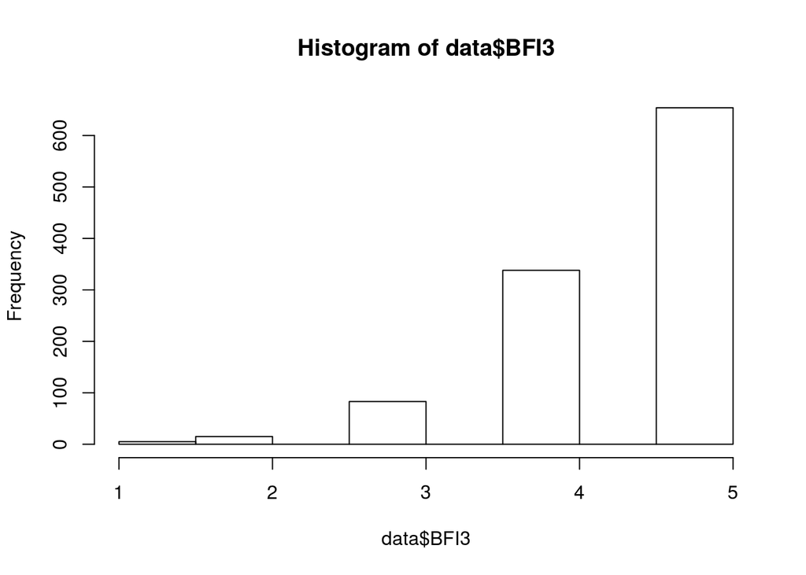

```r
hist(data$BFI3)
```

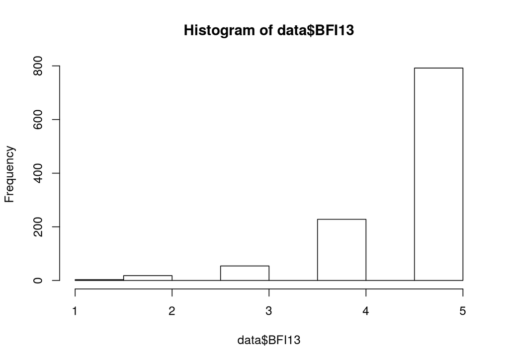

```r
hist(data$BFI13)
```

They’re really skewed. Removing them from the scale entirely may fix the invariance (though it changes the scale, unfortunately). I’ll start by just removing 3.

```r
consci_mod = '
Consci =~ BFI13 + BFI33 + BFI8 + BFI28 + BFI38 + BFI18 + BFI23 + BFI43'

consci_cfa_g_mod = cfa(consci_mod, data = data, group = 'inc_group')
consci_cfa_g_loadings_mod = cfa(consci_mod, data = data, group = 'inc_group', group.equal = 'loadings')
lavTestLRT(consci_cfa_g_loadings_mod, consci_cfa_g_mod)
```

```
## Chi Square Difference Test
##
##                            Df   AIC   BIC  Chisq Chisq diff Df diff
## consci_cfa_g_mod          140 21573 22403 484.17
## consci_cfa_g_loadings_mod 182 21555 22178 550.22     66.053      42
##                           Pr(>Chisq)
## consci_cfa_g_mod
## consci_cfa_g_loadings_mod    0.01034 *
## ---
## Signif. codes:  0 '***' 0.001 '**' 0.01 '*' 0.05 '.' 0.1 ' ' 1
```

```r
fitmeasures(consci_cfa_g_loadings_mod, fit.measures = fms) -
  fitmeasures(consci_cfa_g_mod, fit.measures = fms)
```

```
##    mfi  rmsea    cfi
## -0.010 -0.012 -0.010
```

The MFI difference is acceptable now. So it appears we succeeded in establishing invariance. We could probably do better by removing 13 as well.

```r
consci_mod = '
Consci =~ BFI33 + BFI8 + BFI28 + BFI38 + BFI18 + BFI23 + BFI43'

consci_cfa_g_mod = cfa(consci_mod, data = data, group = 'inc_group')
consci_cfa_g_loadings_mod = cfa(consci_mod, data = data, group = 'inc_group', group.equal = 'loadings')
lavTestLRT(consci_cfa_g_loadings_mod, consci_cfa_g_mod)
```

```
## Chi Square Difference Test
##
##                            Df   AIC   BIC  Chisq Chisq diff Df diff
## consci_cfa_g_mod           98 19741 20467 338.96
## consci_cfa_g_loadings_mod 134 19717 20265 386.86     47.898      36
##                           Pr(>Chisq)
## consci_cfa_g_mod
## consci_cfa_g_loadings_mod    0.08872 .
## ---
## Signif. codes:  0 '***' 0.001 '**' 0.01 '*' 0.05 '.' 0.1 ' ' 1
```

```r
fitmeasures(consci_cfa_g_loadings_mod, fit.measures = fms) -
  fitmeasures(consci_cfa_g_mod, fit.measures = fms)
```

```
##    mfi  rmsea    cfi
## -0.005 -0.016 -0.006
```

Even better. For the hypothesis tests, we will have to check the difference when we use the modified versus unmodified model.

# Hypothesis 1

1.) The hypothesis about the relation of SES to the relative value of immediate gains will be tested with the significance test on the covariance between beta and INR. Delta, planfulness, Conscientiousness, and Impulsivity scale scores will be included in the model as covariates. We expect smaller beta values to be associated with lower INR.

```r
hypo1 ='
  Planfulness =~ P_Q3RTP + P_Q1TP + P_Q7TP + P_Q11RTP + P_Q14TP + P_Q20RTP + P_Q23TP + P_QR25TP +  P_Q28TP +  P_Q30RTP + P_Q2RCS +  P_Q4RCS + P_Q5CS +  P_Q8CS +  P_Q12RCS +  P_Q15CS + P_Q17CS +   P_Q18RCS + P_Q21RCS +   P_Q26CS + P_Q6RMF +  P_Q9MF +   P_Q10RMF +  P_Q13RMF +  P_Q16MF +   P_Q19MF +   P_Q22RMF +  P_Q24MF +   P_Q27MF +   P_Q29RMF
  BIS =~ BIS1 + BIS2 +  BIS3 + BIS4 +   BIS5 +  BIS6 +  BIS7 +  BIS8 +  BIS9 +  BIS10 + BIS11 + BIS12 + BIS13 + BIS14 +    BIS15 +  BIS16 + BIS17 + BIS18 + BIS19 + BIS20 + BIS21 + BIS22 + BIS23 + BIS24 + BIS25 + BIS26 + BIS27 + BIS28 +       BIS29 +   BIS30
  Consci =~ BFI3 + BFI13 + BFI28 + BFI33 + BFI38 + BFI8 + BFI18 + BFI23 + BFI43
  Planfulness ~~ 0*BIS
  Planfulness ~~ 0*Consci
  BIS ~~ 0*Consci
  b ~ d + Planfulness + Consci + BIS
  INR ~ d + Planfulness + Consci + BIS
  b ~~ INR
'
hypo1.fit = cfa(hypo1, data = data)
summary(hypo1.fit, fit.measures=TRUE, standardized=TRUE)
```

```
## lavaan 0.6-3 ended normally after 251 iterations
##
##   Optimization method                           NLMINB
##   Number of free parameters                        149
##
##                                                   Used       Total
##   Number of observations                          1018        1100
##
##   Estimator                                         ML
##   Model Fit Test Statistic                   14802.478
##   Degrees of freedom                              2478
##   P-value (Chi-square)                           0.000
##
## Model test baseline model:
##
##   Minimum Function Test Statistic            30495.907
##   Degrees of freedom                              2556
##   P-value                                        0.000
##
## User model versus baseline model:
##
##   Comparative Fit Index (CFI)                    0.559
##   Tucker-Lewis Index (TLI)                       0.545
##
## Loglikelihood and Information Criteria:
##
##   Loglikelihood user model (H0)             -86386.359
##   Loglikelihood unrestricted model (H1)     -78985.119
##
##   Number of free parameters                        149
##   Akaike (AIC)                              173070.717
##   Bayesian (BIC)                            173804.631
##   Sample-size adjusted Bayesian (BIC)       173331.393
##
## Root Mean Square Error of Approximation:
##
##   RMSEA                                          0.070
##   90 Percent Confidence Interval          0.069  0.071
##   P-value RMSEA <= 0.05                          0.000
##
```

[output cut: 169 more lines]

```
##    .BIS30             0.625    0.028   22.177    0.000    0.625    0.873
##    .BFI3              0.313    0.016   19.857    0.000    0.313    0.583
##    .BFI13             0.286    0.014   20.529    0.000    0.286    0.650
##    .BFI28             0.464    0.024   19.657    0.000    0.464    0.566
##    .BFI33             0.331    0.017   19.149    0.000    0.331    0.526
##    .BFI38             0.571    0.028   20.468    0.000    0.571    0.643
##    .BFI8              0.909    0.045   20.378    0.000    0.909    0.634
##    .BFI18             1.106    0.055   20.277    0.000    1.106    0.623
##    .BFI23             0.868    0.045   19.205    0.000    0.868    0.530
##    .BFI43             1.041    0.050   20.805    0.000    1.041    0.682
##    .b                 0.006    0.000   22.551    0.000    0.006    0.406
##    .INR              34.128    1.520   22.456    0.000   34.128    0.952
##     Planfulness       0.023    0.009    2.419    0.016    1.000    1.000
##     BIS               0.144    0.018    8.164    0.000    1.000    1.000
##     Consci            0.224    0.021   10.799    0.000    1.000    1.000
```

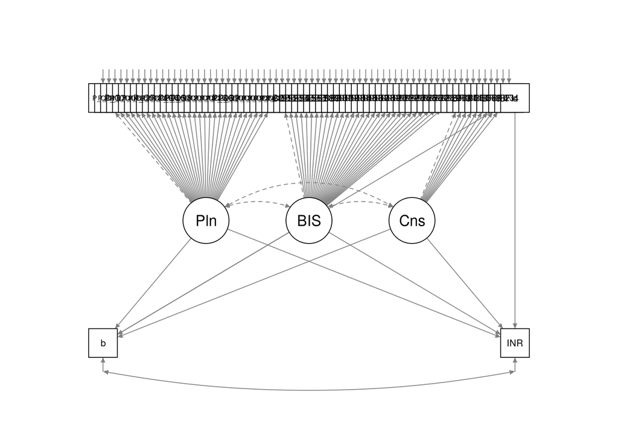

```r
semPaths(hypo1.fit, style="LISREL")
```

## Measurement invariance

```r
hypo1.cmod ='
  Planfulness =~ P_Q3RTP + P_Q1TP + P_Q7TP + P_Q11RTP + P_Q14TP + P_Q20RTP + P_Q23TP + P_QR25TP +  P_Q28TP +  P_Q30RTP + P_Q2RCS +  P_Q4RCS + P_Q5CS +  P_Q8CS +  P_Q12RCS +  P_Q15CS + P_Q17CS +   P_Q18RCS + P_Q21RCS +   P_Q26CS + P_Q6RMF +  P_Q9MF +   P_Q10RMF +  P_Q13RMF +  P_Q16MF +   P_Q19MF +   P_Q22RMF +  P_Q24MF +   P_Q27MF +   P_Q29RMF
  BIS =~ BIS1 + BIS2 +  BIS3 + BIS4 +   BIS5 +  BIS6 +  BIS7 +  BIS8 +  BIS9 +  BIS10 + BIS11 + BIS12 + BIS13 + BIS14 +    BIS15 +  BIS16 + BIS17 + BIS18 + BIS19 + BIS20 + BIS21 + BIS22 + BIS23 + BIS24 + BIS25 + BIS26 + BIS27 + BIS28 +       BIS29 +   BIS30
  Consci =~ BFI28 + BFI33 + BFI38 + BFI8 + BFI18 + BFI23 + BFI43
  Planfulness ~~ 0*BIS
  Planfulness ~~ 0*Consci
  BIS ~~ 0*Consci
  b ~ d + Planfulness + Consci + BIS
  INR ~ d + Planfulness + Consci + BIS
  b ~~ INR
'

hypo1.cmod.fit = cfa(hypo1.cmod, data = data)
summary(hypo1.cmod.fit)
```

```
## lavaan 0.6-3 ended normally after 230 iterations
##
##   Optimization method                           NLMINB
##   Number of free parameters                        145
##
##                                                   Used       Total
##   Number of observations                          1018        1100
##
##   Estimator                                         ML
##   Model Fit Test Statistic                   14327.709
##   Degrees of freedom                              2339
##   P-value (Chi-square)                           0.000
##
## Parameter Estimates:
##
##   Information                                 Expected
##   Information saturated (h1) model          Structured
##   Standard Errors                             Standard
##
## Latent Variables:
##                    Estimate  Std.Err  z-value  P(>|z|)
##   Planfulness =~
##     P_Q3RTP           1.000
##     P_Q1TP            1.881    0.416    4.524    0.000
##     P_Q7TP            3.944    0.824    4.787    0.000
##     P_Q11RTP          3.051    0.667    4.571    0.000
##     P_Q14TP           3.348    0.708    4.729    0.000
##     P_Q20RTP          4.527    0.948    4.775    0.000
##     P_Q23TP           1.846    0.418    4.414    0.000
##     P_QR25TP          1.406    0.358    3.932    0.000
##     P_Q28TP           1.573    0.373    4.219    0.000
##     P_Q30RTP          3.755    0.795    4.724    0.000
##     P_Q2RCS           2.451    0.543    4.517    0.000
##     P_Q4RCS           2.440    0.549    4.445    0.000
##     P_Q5CS            3.444    0.721    4.778    0.000
##     P_Q8CS            3.378    0.707    4.781    0.000
##     P_Q12RCS          2.682    0.597    4.496    0.000
##     P_Q15CS           3.209    0.671    4.785    0.000
##     P_Q17CS           2.953    0.620    4.765    0.000
##     P_Q18RCS          1.694    0.414    4.097    0.000
```

[output cut: 134 more lines]

```
##    .BIS28             0.644    0.030   21.814    0.000
##    .BIS29             0.926    0.041   22.412    0.000
##    .BIS30             0.626    0.028   22.178    0.000
##    .BFI28             0.548    0.027   20.317    0.000
##    .BFI33             0.394    0.020   19.867    0.000
##    .BFI38             0.612    0.030   20.534    0.000
##    .BFI8              0.786    0.042   18.824    0.000
##    .BFI18             0.935    0.051   18.484    0.000
##    .BFI23             0.775    0.044   17.499    0.000
##    .BFI43             0.911    0.047   19.506    0.000
##    .b                 0.006    0.000   22.548    0.000
##    .INR              34.216    1.521   22.490    0.000
##     Planfulness       0.023    0.009    2.416    0.016
##     BIS               0.144    0.018    8.157    0.000
##     Consci            0.273    0.030    9.242    0.000
```

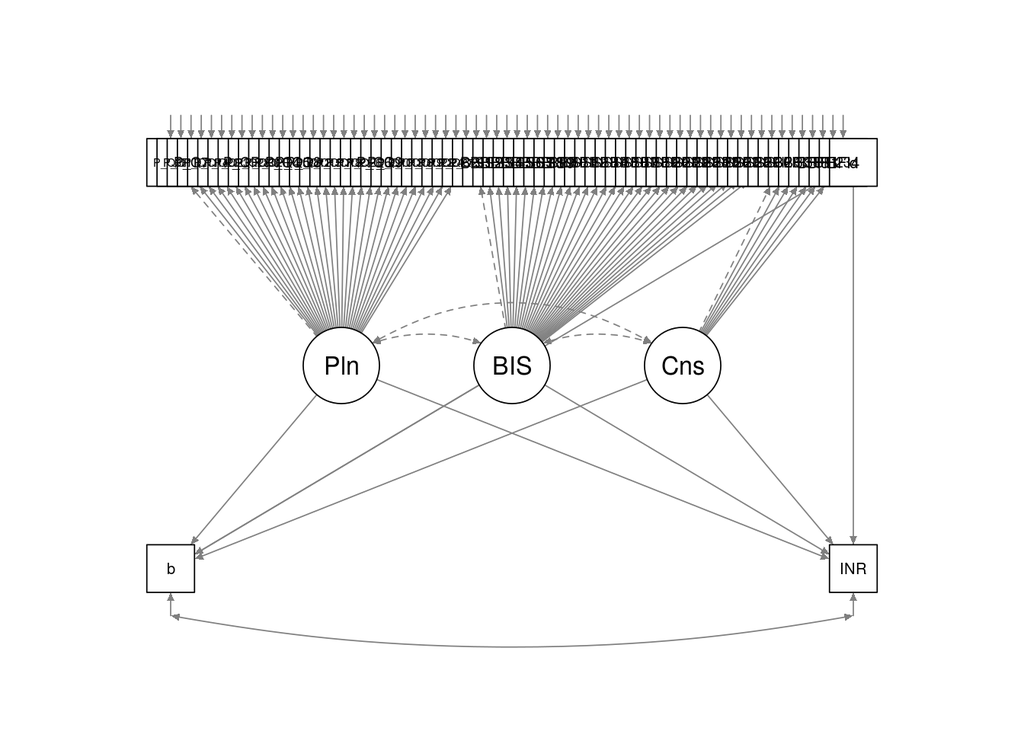

```r
semPaths(hypo1.cmod.fit, style="LISREL")
```

## Free Cov

```r
hypo1.fc ='
  Planfulness =~ P_Q3RTP + P_Q1TP + P_Q7TP + P_Q11RTP + P_Q14TP + P_Q20RTP + P_Q23TP + P_QR25TP +  P_Q28TP +  P_Q30RTP + P_Q2RCS +  P_Q4RCS + P_Q5CS +  P_Q8CS +  P_Q12RCS +  P_Q15CS + P_Q17CS +   P_Q18RCS + P_Q21RCS +   P_Q26CS + P_Q6RMF +  P_Q9MF +   P_Q10RMF +  P_Q13RMF +  P_Q16MF +   P_Q19MF +   P_Q22RMF +  P_Q24MF +   P_Q27MF +   P_Q29RMF
  BIS =~ BIS1 + BIS2 +  BIS3 + BIS4 +   BIS5 +  BIS6 +  BIS7 +  BIS8 +  BIS9 +  BIS10 + BIS11 + BIS12 + BIS13 + BIS14 +    BIS15 +  BIS16 + BIS17 + BIS18 + BIS19 + BIS20 + BIS21 + BIS22 + BIS23 + BIS24 + BIS25 + BIS26 + BIS27 + BIS28 +       BIS29 +   BIS30
  Consci =~ BFI3 + BFI13 + BFI28 + BFI33 + BFI38 + BFI8 + BFI18 + BFI23 + BFI43
  b ~ d + Planfulness + Consci + BIS
  INR ~ d + Planfulness + Consci + BIS
  b ~~ INR
'
hypo1.fc.fit = cfa(hypo1.fc, data = data)
summary(hypo1.fc.fit, fit.measures=TRUE, standardized=TRUE)
```

```
## lavaan 0.6-3 ended normally after 246 iterations
##
##   Optimization method                           NLMINB
##   Number of free parameters                        152
##
##                                                   Used       Total
##   Number of observations                          1018        1100
##
##   Estimator                                         ML
##   Model Fit Test Statistic                   13310.731
##   Degrees of freedom                              2475
##   P-value (Chi-square)                           0.000
##
## Model test baseline model:
##
##   Minimum Function Test Statistic            30495.907
##   Degrees of freedom                              2556
##   P-value                                        0.000
##
## User model versus baseline model:
##
##   Comparative Fit Index (CFI)                    0.612
##   Tucker-Lewis Index (TLI)                       0.599
##
## Loglikelihood and Information Criteria:
##
##   Loglikelihood user model (H0)             -85640.485
##   Loglikelihood unrestricted model (H1)     -78985.119
##
##   Number of free parameters                        152
##   Akaike (AIC)                              171584.970
##   Bayesian (BIC)                            172333.660
##   Sample-size adjusted Bayesian (BIC)       171850.894
##
## Root Mean Square Error of Approximation:
##
##   RMSEA                                          0.066
##   90 Percent Confidence Interval          0.064  0.067
##   P-value RMSEA <= 0.05                          0.000
##
```

[output cut: 169 more lines]

```
##    .BIS30             0.590    0.027   22.109    0.000    0.590    0.823
##    .BFI3              0.336    0.016   20.829    0.000    0.336    0.625
##    .BFI13             0.297    0.014   21.163    0.000    0.297    0.674
##    .BFI28             0.485    0.024   20.561    0.000    0.485    0.591
##    .BFI33             0.343    0.017   20.144    0.000    0.343    0.545
##    .BFI38             0.557    0.027   20.845    0.000    0.557    0.628
##    .BFI8              0.859    0.042   20.623    0.000    0.859    0.599
##    .BFI18             1.088    0.052   20.733    0.000    1.088    0.613
##    .BFI23             0.868    0.043   19.992    0.000    0.868    0.530
##    .BFI43             0.965    0.046   20.880    0.000    0.965    0.632
##    .b                 0.006    0.000   22.533    0.000    0.006    0.406
##    .INR              33.945    1.519   22.354    0.000   33.945    0.943
##     Planfulness       0.028    0.010    2.691    0.007    1.000    1.000
##     BIS               0.178    0.019    9.332    0.000    1.000    1.000
##     Consci            0.201    0.020   10.274    0.000    1.000    1.000
```

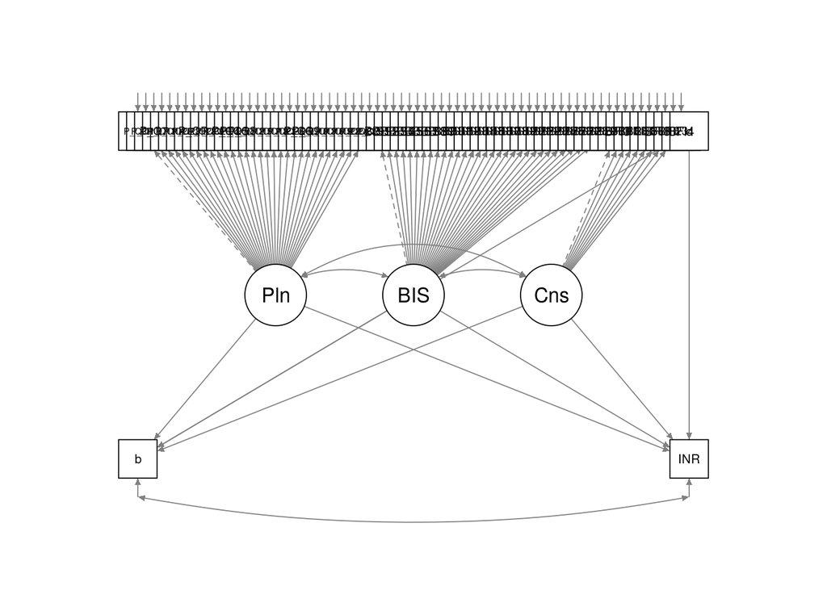

```r
semPaths(hypo1.fc.fit, style="LISREL")
```

## Log INR

```r
hypo1.loginr ='
  Planfulness =~ P_Q3RTP + P_Q1TP + P_Q7TP + P_Q11RTP + P_Q14TP + P_Q20RTP + P_Q23TP + P_QR25TP +  P_Q28TP +  P_Q30RTP + P_Q2RCS +  P_Q4RCS + P_Q5CS +  P_Q8CS +  P_Q12RCS +  P_Q15CS + P_Q17CS +   P_Q18RCS + P_Q21RCS +   P_Q26CS + P_Q6RMF +  P_Q9MF +   P_Q10RMF +  P_Q13RMF +  P_Q16MF +   P_Q19MF +   P_Q22RMF +  P_Q24MF +   P_Q27MF +   P_Q29RMF
  BIS =~ BIS1 + BIS2 +  BIS3 + BIS4 +   BIS5 +  BIS6 +  BIS7 +  BIS8 +  BIS9 +  BIS10 + BIS11 + BIS12 + BIS13 + BIS14 +    BIS15 +  BIS16 + BIS17 + BIS18 + BIS19 + BIS20 + BIS21 + BIS22 + BIS23 + BIS24 + BIS25 + BIS26 + BIS27 + BIS28 +       BIS29 +   BIS30
  Consci =~ BFI3 + BFI13 + BFI28 + BFI33 + BFI38 + BFI8 + BFI18 + BFI23 + BFI43
  Planfulness ~~ 0*BIS
  Planfulness ~~ 0*Consci
  BIS ~~ 0*Consci
  b ~ d + Planfulness + Consci + BIS
  logINR ~ d + Planfulness + Consci + BIS
  b ~~ logINR
'
hypo1.loginr.fit = cfa(hypo1.loginr, data = data)
summary(hypo1.loginr.fit, fit.measures=TRUE, standardized=TRUE)
```

```
## lavaan 0.6-3 ended normally after 158 iterations
##
##   Optimization method                           NLMINB
##   Number of free parameters                        149
##
##                                                   Used       Total
##   Number of observations                          1018        1100
##
##   Estimator                                         ML
##   Model Fit Test Statistic                   14857.755
##   Degrees of freedom                              2478
##   P-value (Chi-square)                           0.000
##
## Model test baseline model:
##
##   Minimum Function Test Statistic            30557.608
##   Degrees of freedom                              2556
##   P-value                                        0.000
##
## User model versus baseline model:
##
##   Comparative Fit Index (CFI)                    0.558
##   Tucker-Lewis Index (TLI)                       0.544
##
## Loglikelihood and Information Criteria:
##
##   Loglikelihood user model (H0)             -84564.488
##   Loglikelihood unrestricted model (H1)     -77135.611
##
##   Number of free parameters                        149
##   Akaike (AIC)                              169426.977
##   Bayesian (BIC)                            170160.890
##   Sample-size adjusted Bayesian (BIC)       169687.653
##
## Root Mean Square Error of Approximation:
##
##   RMSEA                                          0.070
##   90 Percent Confidence Interval          0.069  0.071
##   P-value RMSEA <= 0.05                          0.000
##
```

[output cut: 169 more lines]

```
##    .BIS30             0.625    0.028   22.177    0.000    0.625    0.872
##    .BFI3              0.313    0.016   19.851    0.000    0.313    0.582
##    .BFI13             0.287    0.014   20.533    0.000    0.287    0.650
##    .BFI28             0.464    0.024   19.658    0.000    0.464    0.566
##    .BFI33             0.331    0.017   19.151    0.000    0.331    0.526
##    .BFI38             0.571    0.028   20.471    0.000    0.571    0.644
##    .BFI8              0.908    0.045   20.376    0.000    0.908    0.633
##    .BFI18             1.106    0.055   20.276    0.000    1.106    0.623
##    .BFI23             0.869    0.045   19.212    0.000    0.869    0.530
##    .BFI43             1.040    0.050   20.804    0.000    1.040    0.682
##    .b                 0.006    0.000   22.551    0.000    0.006    0.406
##    .logINR            0.947    0.042   22.423    0.000    0.947    0.940
##     Planfulness       0.023    0.009    2.419    0.016    1.000    1.000
##     BIS               0.145    0.018    8.169    0.000    1.000    1.000
##     Consci            0.224    0.021   10.810    0.000    1.000    1.000
```

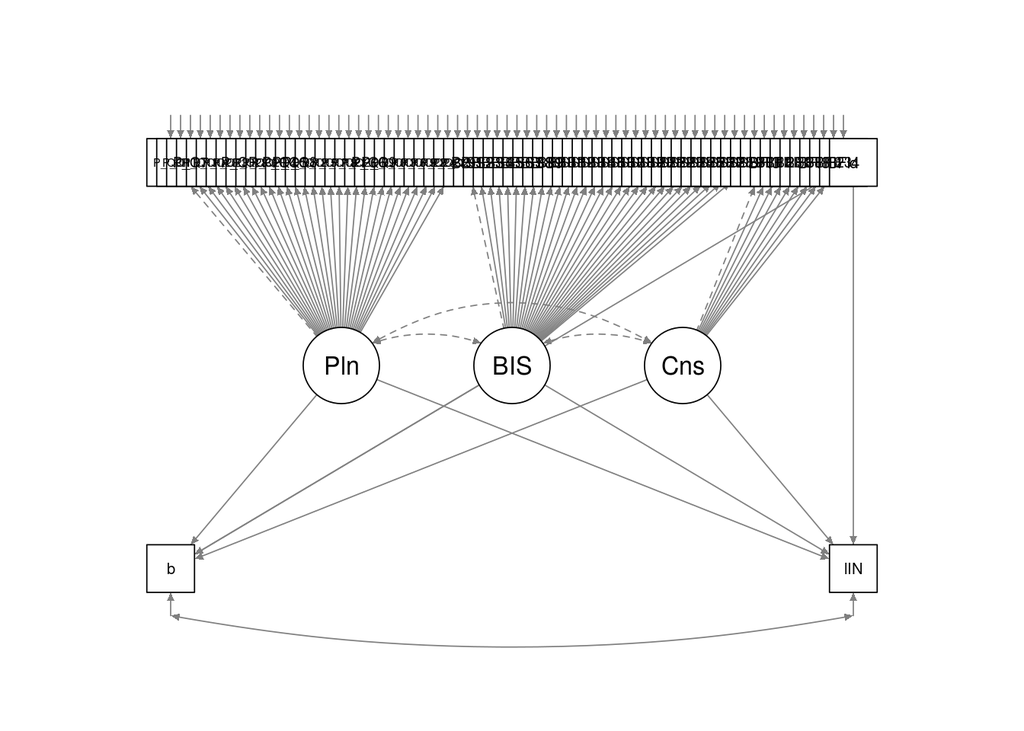

```r
semPaths(hypo1.loginr.fit, style="LISREL")
```

### Free Cov

```r
hypo1.fc.loginr ='
  Planfulness =~ P_Q3RTP + P_Q1TP + P_Q7TP + P_Q11RTP + P_Q14TP + P_Q20RTP + P_Q23TP + P_QR25TP +  P_Q28TP +  P_Q30RTP + P_Q2RCS +  P_Q4RCS + P_Q5CS +  P_Q8CS +  P_Q12RCS +  P_Q15CS + P_Q17CS +   P_Q18RCS + P_Q21RCS +   P_Q26CS + P_Q6RMF +  P_Q9MF +   P_Q10RMF +  P_Q13RMF +  P_Q16MF +   P_Q19MF +   P_Q22RMF +  P_Q24MF +   P_Q27MF +   P_Q29RMF
  BIS =~ BIS1 + BIS2 +  BIS3 + BIS4 +   BIS5 +  BIS6 +  BIS7 +  BIS8 +  BIS9 +  BIS10 + BIS11 + BIS12 + BIS13 + BIS14 +    BIS15 +  BIS16 + BIS17 + BIS18 + BIS19 + BIS20 + BIS21 + BIS22 + BIS23 + BIS24 + BIS25 + BIS26 + BIS27 + BIS28 +       BIS29 +   BIS30
  Consci =~ BFI3 + BFI13 + BFI28 + BFI33 + BFI38 + BFI8 + BFI18 + BFI23 + BFI43
  b ~ d + Planfulness + Consci + BIS
  logINR ~ d + Planfulness + Consci + BIS
  b ~~ logINR
'
hypo1.fc.loginr.fit = cfa(hypo1.fc.loginr, data = data)
summary(hypo1.fc.loginr.fit, fit.measures=TRUE, standardized=TRUE)
```

```
## lavaan 0.6-3 ended normally after 185 iterations
##
##   Optimization method                           NLMINB
##   Number of free parameters                        152
##
##                                                   Used       Total
##   Number of observations                          1018        1100
##
##   Estimator                                         ML
##   Model Fit Test Statistic                   13365.280
##   Degrees of freedom                              2475
##   P-value (Chi-square)                           0.000
##
## Model test baseline model:
##
##   Minimum Function Test Statistic            30557.608
##   Degrees of freedom                              2556
##   P-value                                        0.000
##
## User model versus baseline model:
##
##   Comparative Fit Index (CFI)                    0.611
##   Tucker-Lewis Index (TLI)                       0.598
##
## Loglikelihood and Information Criteria:
##
##   Loglikelihood user model (H0)             -83818.251
##   Loglikelihood unrestricted model (H1)     -77135.611
##
##   Number of free parameters                        152
##   Akaike (AIC)                              167940.502
##   Bayesian (BIC)                            168689.192
##   Sample-size adjusted Bayesian (BIC)       168206.426
##
## Root Mean Square Error of Approximation:
##
##   RMSEA                                          0.066
##   90 Percent Confidence Interval          0.065  0.067
##   P-value RMSEA <= 0.05                          0.000
##
```

[output cut: 169 more lines]

```
##    .BIS30             0.590    0.027   22.109    0.000    0.590    0.822
##    .BFI3              0.335    0.016   20.825    0.000    0.335    0.625
##    .BFI13             0.297    0.014   21.167    0.000    0.297    0.674
##    .BFI28             0.485    0.024   20.562    0.000    0.485    0.591
##    .BFI33             0.343    0.017   20.147    0.000    0.343    0.545
##    .BFI38             0.557    0.027   20.849    0.000    0.557    0.628
##    .BFI8              0.859    0.042   20.622    0.000    0.859    0.599
##    .BFI18             1.087    0.052   20.733    0.000    1.087    0.613
##    .BFI23             0.869    0.043   19.998    0.000    0.869    0.531
##    .BFI43             0.964    0.046   20.879    0.000    0.964    0.632
##    .b                 0.006    0.000   22.533    0.000    0.006    0.406
##    .logINR            0.941    0.042   22.274    0.000    0.941    0.931
##     Planfulness       0.028    0.010    2.690    0.007    1.000    1.000
##     BIS               0.178    0.019    9.334    0.000    1.000    1.000
##     Consci            0.201    0.020   10.285    0.000    1.000    1.000
```

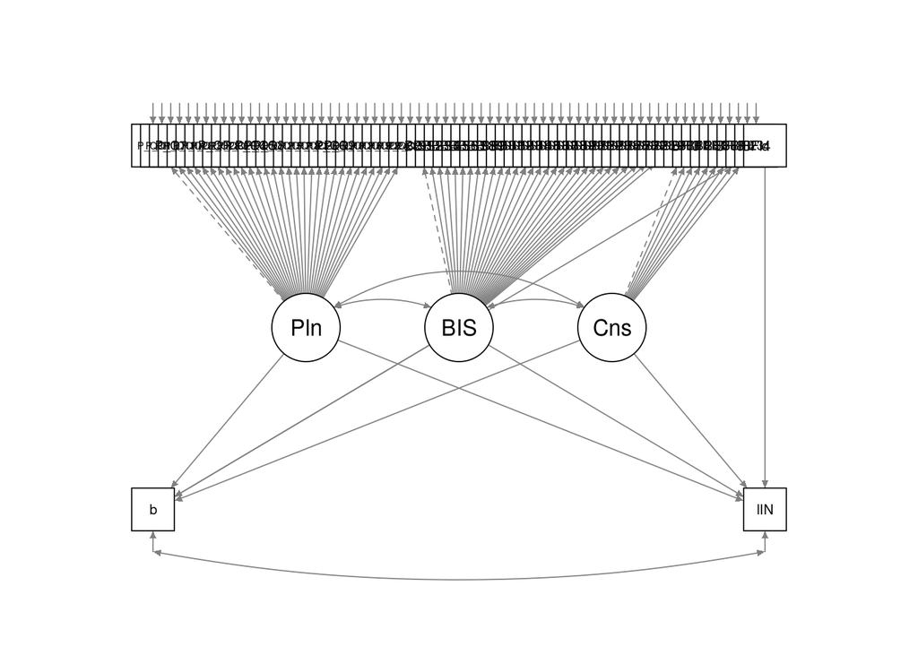

```r
semPaths(hypo1.fc.loginr.fit, style="LISREL")
```

# Hypothesis 2

2.) The hypothesis about the relation of SES to the value of long-term gains will be tested with the significance test on the covariance between delta and INR. Planfulness, Conscientiousness, and Impulsivity scale scores will be included in the model as covariates. We expect smaller delta values to be associated with lower INR.

```r
hypo2 ='
  Planfulness =~ P_Q3RTP + P_Q1TP + P_Q7TP + P_Q11RTP + P_Q14TP + P_Q20RTP + P_Q23TP + P_QR25TP +  P_Q28TP +  P_Q30RTP + P_Q2RCS +  P_Q4RCS + P_Q5CS +  P_Q8CS +  P_Q12RCS +  P_Q15CS + P_Q17CS +   P_Q18RCS + P_Q21RCS +   P_Q26CS + P_Q6RMF +  P_Q9MF +   P_Q10RMF +  P_Q13RMF +  P_Q16MF +   P_Q19MF +   P_Q22RMF +  P_Q24MF +   P_Q27MF +   P_Q29RMF
  BIS =~ BIS1 + BIS2 +  BIS3 + BIS4 +   BIS5 +  BIS6 +  BIS7 +  BIS8 +  BIS9 +  BIS10 + BIS11 + BIS12 + BIS13 + BIS14 +    BIS15 +  BIS16 + BIS17 + BIS18 + BIS19 + BIS20 + BIS21 + BIS22 + BIS23 + BIS24 + BIS25 + BIS26 + BIS27 + BIS28 +       BIS29 +   BIS30
  Consci =~ BFI3 + BFI13 + BFI28 + BFI33 + BFI38 + BFI8 + BFI18 + BFI23 + BFI43
  Planfulness ~~ 0*BIS
  Planfulness ~~ 0*Consci
  BIS ~~ 0*Consci
  d ~ Planfulness + Consci + BIS
  INR ~ Planfulness + Consci + BIS
  d ~~ INR
'
hypo2.fit = cfa(hypo2, data = data)
summary(hypo2.fit, fit.measures=TRUE, standardized=TRUE)
```

```
## lavaan 0.6-3 ended normally after 198 iterations
##
##   Optimization method                           NLMINB
##   Number of free parameters                        147
##
##                                                   Used       Total
##   Number of observations                          1018        1100
##
##   Estimator                                         ML
##   Model Fit Test Statistic                   14728.244
##   Degrees of freedom                              2409
##   P-value (Chi-square)                           0.000
##
## Model test baseline model:
##
##   Minimum Function Test Statistic            29501.940
##   Degrees of freedom                              2485
##   P-value                                        0.000
##
## User model versus baseline model:
##
##   Comparative Fit Index (CFI)                    0.544
##   Tucker-Lewis Index (TLI)                       0.530
##
## Loglikelihood and Information Criteria:
##
##   Loglikelihood user model (H0)             -85116.114
##   Loglikelihood unrestricted model (H1)     -77751.992
##
##   Number of free parameters                        147
##   Akaike (AIC)                              170526.228
##   Bayesian (BIC)                            171250.290
##   Sample-size adjusted Bayesian (BIC)       170783.405
##
## Root Mean Square Error of Approximation:
##
##   RMSEA                                          0.071
##   90 Percent Confidence Interval          0.070  0.072
##   P-value RMSEA <= 0.05                          0.000
##
```

[output cut: 167 more lines]

```
##    .BIS30             0.626    0.028   22.178    0.000    0.626    0.873
##    .BFI3              0.313    0.016   19.861    0.000    0.313    0.583
##    .BFI13             0.286    0.014   20.530    0.000    0.286    0.650
##    .BFI28             0.464    0.024   19.658    0.000    0.464    0.566
##    .BFI33             0.331    0.017   19.153    0.000    0.331    0.526
##    .BFI38             0.571    0.028   20.471    0.000    0.571    0.644
##    .BFI8              0.908    0.045   20.375    0.000    0.908    0.633
##    .BFI18             1.105    0.055   20.275    0.000    1.105    0.623
##    .BFI23             0.867    0.045   19.202    0.000    0.867    0.530
##    .BFI43             1.040    0.050   20.802    0.000    1.040    0.682
##    .d                 0.000    0.000   22.544    0.000    0.000    0.992
##    .INR              34.208    1.523   22.454    0.000   34.208    0.953
##     Planfulness       0.023    0.009    2.426    0.015    1.000    1.000
##     BIS               0.144    0.018    8.157    0.000    1.000    1.000
##     Consci            0.224    0.021   10.795    0.000    1.000    1.000
```

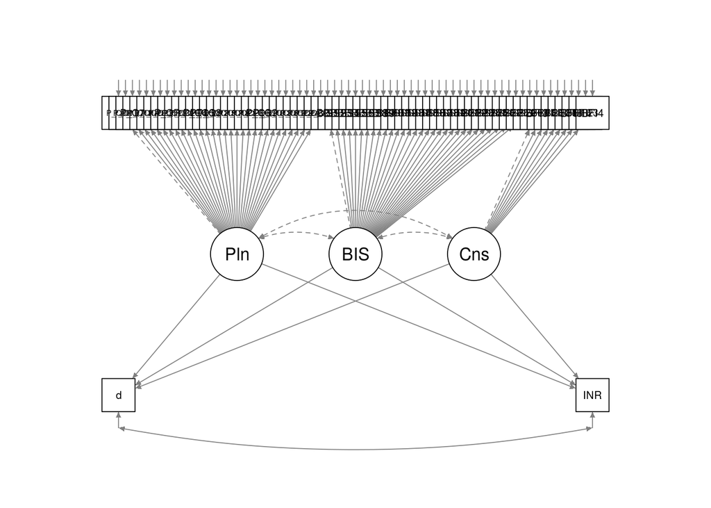

```r
semPaths(hypo2.fit, style="LISREL")
```

## Measurement invariance

```r
hypo2.cmod ='
  Planfulness =~ P_Q3RTP + P_Q1TP + P_Q7TP + P_Q11RTP + P_Q14TP + P_Q20RTP + P_Q23TP + P_QR25TP +  P_Q28TP +  P_Q30RTP + P_Q2RCS +  P_Q4RCS + P_Q5CS +  P_Q8CS +  P_Q12RCS +  P_Q15CS + P_Q17CS +   P_Q18RCS + P_Q21RCS +   P_Q26CS + P_Q6RMF +  P_Q9MF +   P_Q10RMF +  P_Q13RMF +  P_Q16MF +   P_Q19MF +   P_Q22RMF +  P_Q24MF +   P_Q27MF +   P_Q29RMF
  BIS =~ BIS1 + BIS2 +  BIS3 + BIS4 +   BIS5 +  BIS6 +  BIS7 +  BIS8 +  BIS9 +  BIS10 + BIS11 + BIS12 + BIS13 + BIS14 +    BIS15 +  BIS16 + BIS17 + BIS18 + BIS19 + BIS20 + BIS21 + BIS22 + BIS23 + BIS24 + BIS25 + BIS26 + BIS27 + BIS28 +       BIS29 +   BIS30
  Consci =~ BFI28 + BFI33 + BFI38 + BFI8 + BFI18 + BFI23 + BFI43
  Planfulness ~~ 0*BIS
  Planfulness ~~ 0*Consci
  BIS ~~ 0*Consci
  d ~ Planfulness + Consci + BIS
  INR ~ Planfulness + Consci + BIS
  d ~~ INR
'
hypo2.cmod.fit = cfa(hypo2.cmod, data = data)
summary(hypo2.cmod.fit)
```

```
## lavaan 0.6-3 ended normally after 200 iterations
##
##   Optimization method                           NLMINB
##   Number of free parameters                        143
##
##                                                   Used       Total
##   Number of observations                          1018        1100
##
##   Estimator                                         ML
##   Model Fit Test Statistic                   14253.280
##   Degrees of freedom                              2272
##   P-value (Chi-square)                           0.000
##
## Parameter Estimates:
##
##   Information                                 Expected
##   Information saturated (h1) model          Structured
##   Standard Errors                             Standard
##
## Latent Variables:
##                    Estimate  Std.Err  z-value  P(>|z|)
##   Planfulness =~
##     P_Q3RTP           1.000
##     P_Q1TP            1.876    0.414    4.536    0.000
##     P_Q7TP            3.931    0.819    4.801    0.000
##     P_Q11RTP          3.042    0.664    4.583    0.000
##     P_Q14TP           3.339    0.704    4.743    0.000
##     P_Q20RTP          4.515    0.943    4.789    0.000
##     P_Q23TP           1.843    0.416    4.426    0.000
##     P_QR25TP          1.402    0.356    3.940    0.000
##     P_Q28TP           1.568    0.371    4.228    0.000
##     P_Q30RTP          3.745    0.791    4.738    0.000
##     P_Q2RCS           2.443    0.539    4.528    0.000
##     P_Q4RCS           2.436    0.546    4.457    0.000
##     P_Q5CS            3.433    0.716    4.792    0.000
##     P_Q8CS            3.367    0.702    4.795    0.000
##     P_Q12RCS          2.674    0.593    4.507    0.000
##     P_Q15CS           3.198    0.666    4.799    0.000
##     P_Q17CS           2.945    0.616    4.779    0.000
##     P_Q18RCS          1.691    0.412    4.107    0.000
```

[output cut: 132 more lines]

```
##    .BIS28             0.644    0.030   21.813    0.000
##    .BIS29             0.926    0.041   22.413    0.000
##    .BIS30             0.626    0.028   22.179    0.000
##    .BFI28             0.548    0.027   20.321    0.000
##    .BFI33             0.394    0.020   19.874    0.000
##    .BFI38             0.612    0.030   20.542    0.000
##    .BFI8              0.786    0.042   18.819    0.000
##    .BFI18             0.935    0.051   18.485    0.000
##    .BFI23             0.775    0.044   17.501    0.000
##    .BFI43             0.910    0.047   19.503    0.000
##    .d                 0.000    0.000   22.535    0.000
##    .INR              34.299    1.525   22.488    0.000
##     Planfulness       0.023    0.009    2.423    0.015
##     BIS               0.144    0.018    8.148    0.000
##     Consci            0.273    0.030    9.240    0.000
```

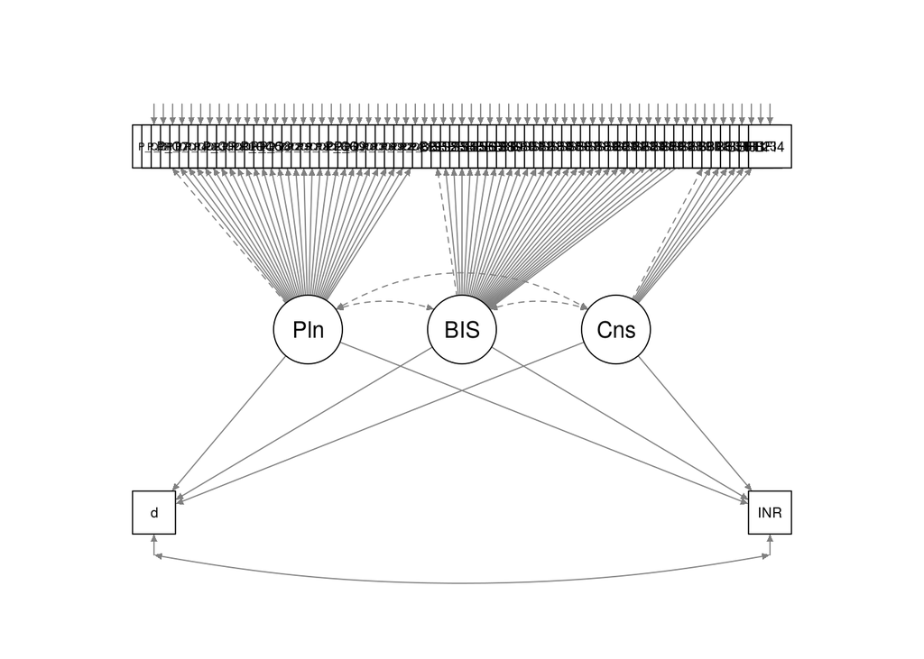

```r
semPaths(hypo2.cmod.fit, style="LISREL")
```

## Free Cov

```r
hypo2.fc ='
  Planfulness =~ P_Q3RTP + P_Q1TP + P_Q7TP + P_Q11RTP + P_Q14TP + P_Q20RTP + P_Q23TP + P_QR25TP +  P_Q28TP +  P_Q30RTP + P_Q2RCS +  P_Q4RCS + P_Q5CS +  P_Q8CS +  P_Q12RCS +  P_Q15CS + P_Q17CS +   P_Q18RCS + P_Q21RCS +   P_Q26CS + P_Q6RMF +  P_Q9MF +   P_Q10RMF +  P_Q13RMF +  P_Q16MF +   P_Q19MF +   P_Q22RMF +  P_Q24MF +   P_Q27MF +   P_Q29RMF
  BIS =~ BIS1 + BIS2 +  BIS3 + BIS4 +   BIS5 +  BIS6 +  BIS7 +  BIS8 +  BIS9 +  BIS10 + BIS11 + BIS12 + BIS13 + BIS14 +    BIS15 +  BIS16 + BIS17 + BIS18 + BIS19 + BIS20 + BIS21 + BIS22 + BIS23 + BIS24 + BIS25 + BIS26 + BIS27 + BIS28 +       BIS29 +   BIS30
  Consci =~ BFI3 + BFI13 + BFI28 + BFI33 + BFI38 + BFI8 + BFI18 + BFI23 + BFI43
  d ~ Planfulness + Consci + BIS
  INR ~ Planfulness + Consci + BIS
  d ~~ INR
'
hypo2.fc.fit = cfa(hypo2.fc, data = data)
summary(hypo2.fc.fit, fit.measures=TRUE, standardized=TRUE)
```

```
## lavaan 0.6-3 ended normally after 222 iterations
##
##   Optimization method                           NLMINB
##   Number of free parameters                        150
##
##                                                   Used       Total
##   Number of observations                          1018        1100
##
##   Estimator                                         ML
##   Model Fit Test Statistic                   13236.718
##   Degrees of freedom                              2406
##   P-value (Chi-square)                           0.000
##
## Model test baseline model:
##
##   Minimum Function Test Statistic            29501.940
##   Degrees of freedom                              2485
##   P-value                                        0.000
##
## User model versus baseline model:
##
##   Comparative Fit Index (CFI)                    0.599
##   Tucker-Lewis Index (TLI)                       0.586
##
## Loglikelihood and Information Criteria:
##
##   Loglikelihood user model (H0)             -84370.350
##   Loglikelihood unrestricted model (H1)     -77751.992
##
##   Number of free parameters                        150
##   Akaike (AIC)                              169040.701
##   Bayesian (BIC)                            169779.540
##   Sample-size adjusted Bayesian (BIC)       169303.127
##
## Root Mean Square Error of Approximation:
##
##   RMSEA                                          0.066
##   90 Percent Confidence Interval          0.065  0.068
##   P-value RMSEA <= 0.05                          0.000
##
```

[output cut: 167 more lines]

```
##    .BIS30             0.590    0.027   22.110    0.000    0.590    0.823
##    .BFI3              0.336    0.016   20.831    0.000    0.336    0.626
##    .BFI13             0.297    0.014   21.164    0.000    0.297    0.674
##    .BFI28             0.485    0.024   20.562    0.000    0.485    0.591
##    .BFI33             0.343    0.017   20.147    0.000    0.343    0.546
##    .BFI38             0.557    0.027   20.848    0.000    0.557    0.628
##    .BFI8              0.859    0.042   20.621    0.000    0.859    0.599
##    .BFI18             1.087    0.052   20.732    0.000    1.087    0.613
##    .BFI23             0.868    0.043   19.991    0.000    0.868    0.530
##    .BFI43             0.964    0.046   20.878    0.000    0.964    0.632
##    .d                 0.000    0.000   22.531    0.000    0.000    0.996
##    .INR              34.024    1.522   22.349    0.000   34.024    0.945
##     Planfulness       0.028    0.010    2.698    0.007    1.000    1.000
##     BIS               0.178    0.019    9.323    0.000    1.000    1.000
##     Consci            0.201    0.020   10.271    0.000    1.000    1.000
```

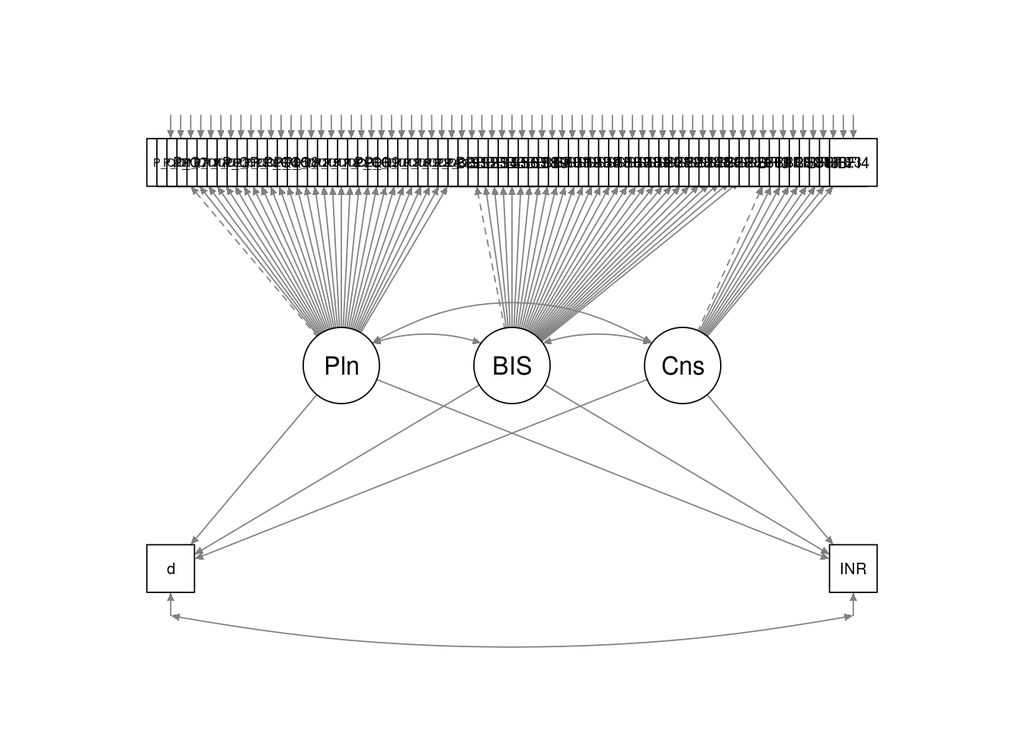

```r
semPaths(hypo2.fc.fit, style="LISREL")
```

## Log INR

```r
hypo2.loginr ='
  Planfulness =~ P_Q3RTP + P_Q1TP + P_Q7TP + P_Q11RTP + P_Q14TP + P_Q20RTP + P_Q23TP + P_QR25TP +  P_Q28TP +  P_Q30RTP + P_Q2RCS +  P_Q4RCS + P_Q5CS +  P_Q8CS +  P_Q12RCS +  P_Q15CS + P_Q17CS +   P_Q18RCS + P_Q21RCS +   P_Q26CS + P_Q6RMF +  P_Q9MF +   P_Q10RMF +  P_Q13RMF +  P_Q16MF +   P_Q19MF +   P_Q22RMF +  P_Q24MF +   P_Q27MF +   P_Q29RMF
  BIS =~ BIS1 + BIS2 +  BIS3 + BIS4 +   BIS5 +  BIS6 +  BIS7 +  BIS8 +  BIS9 +  BIS10 + BIS11 + BIS12 + BIS13 + BIS14 +    BIS15 +  BIS16 + BIS17 + BIS18 + BIS19 + BIS20 + BIS21 + BIS22 + BIS23 + BIS24 + BIS25 + BIS26 + BIS27 + BIS28 +       BIS29 +   BIS30
  Consci =~ BFI3 + BFI13 + BFI28 + BFI33 + BFI38 + BFI8 + BFI18 + BFI23 + BFI43
  Planfulness ~~ 0*BIS
  Planfulness ~~ 0*Consci
  BIS ~~ 0*Consci
  d ~ Planfulness + Consci + BIS
  logINR ~ Planfulness + Consci + BIS
  d ~~ logINR
'
hypo2.loginr.fit = cfa(hypo2.loginr, data = data)
summary(hypo2.loginr.fit, fit.measures=TRUE, standardized=TRUE)
```

```
## lavaan 0.6-3 ended normally after 149 iterations
##
##   Optimization method                           NLMINB
##   Number of free parameters                        147
##
##                                                   Used       Total
##   Number of observations                          1018        1100
##
##   Estimator                                         ML
##   Model Fit Test Statistic                   14782.969
##   Degrees of freedom                              2409
##   P-value (Chi-square)                           0.000
##
## Model test baseline model:
##
##   Minimum Function Test Statistic            29566.682
##   Degrees of freedom                              2485
##   P-value                                        0.000
##
## User model versus baseline model:
##
##   Comparative Fit Index (CFI)                    0.543
##   Tucker-Lewis Index (TLI)                       0.529
##
## Loglikelihood and Information Criteria:
##
##   Loglikelihood user model (H0)             -83292.447
##   Loglikelihood unrestricted model (H1)     -75900.962
##
##   Number of free parameters                        147
##   Akaike (AIC)                              166878.893
##   Bayesian (BIC)                            167602.956
##   Sample-size adjusted Bayesian (BIC)       167136.070
##
## Root Mean Square Error of Approximation:
##
##   RMSEA                                          0.071
##   90 Percent Confidence Interval          0.070  0.072
##   P-value RMSEA <= 0.05                          0.000
##
```

[output cut: 167 more lines]

```
##    .BIS30             0.626    0.028   22.178    0.000    0.626    0.873
##    .BFI3              0.313    0.016   19.854    0.000    0.313    0.583
##    .BFI13             0.287    0.014   20.534    0.000    0.287    0.650
##    .BFI28             0.464    0.024   19.660    0.000    0.464    0.566
##    .BFI33             0.331    0.017   19.156    0.000    0.331    0.526
##    .BFI38             0.571    0.028   20.475    0.000    0.571    0.644
##    .BFI8              0.908    0.045   20.373    0.000    0.908    0.633
##    .BFI18             1.105    0.055   20.275    0.000    1.105    0.623
##    .BFI23             0.868    0.045   19.209    0.000    0.868    0.530
##    .BFI43             1.040    0.050   20.801    0.000    1.040    0.682
##    .d                 0.000    0.000   22.544    0.000    0.000    0.993
##    .logINR            0.949    0.042   22.421    0.000    0.949    0.941
##     Planfulness       0.023    0.009    2.425    0.015    1.000    1.000
##     BIS               0.144    0.018    8.161    0.000    1.000    1.000
##     Consci            0.224    0.021   10.806    0.000    1.000    1.000
```

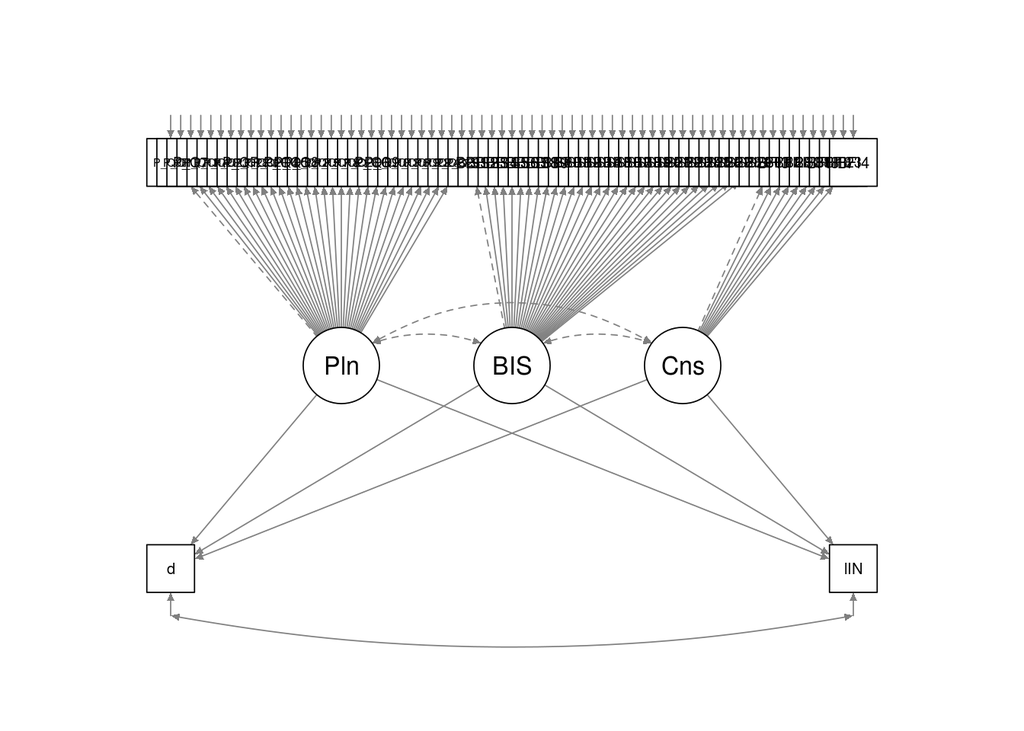

```r
semPaths(hypo2.loginr.fit, style="LISREL")
```

### Free Cov

```r
hypo2.fc.loginr ='
  Planfulness =~ P_Q3RTP + P_Q1TP + P_Q7TP + P_Q11RTP + P_Q14TP + P_Q20RTP + P_Q23TP + P_QR25TP +  P_Q28TP +  P_Q30RTP + P_Q2RCS +  P_Q4RCS + P_Q5CS +  P_Q8CS +  P_Q12RCS +  P_Q15CS + P_Q17CS +   P_Q18RCS + P_Q21RCS +   P_Q26CS + P_Q6RMF +  P_Q9MF +   P_Q10RMF +  P_Q13RMF +  P_Q16MF +   P_Q19MF +   P_Q22RMF +  P_Q24MF +   P_Q27MF +   P_Q29RMF
  BIS =~ BIS1 + BIS2 +  BIS3 + BIS4 +   BIS5 +  BIS6 +  BIS7 +  BIS8 +  BIS9 +  BIS10 + BIS11 + BIS12 + BIS13 + BIS14 +    BIS15 +  BIS16 + BIS17 + BIS18 + BIS19 + BIS20 + BIS21 + BIS22 + BIS23 + BIS24 + BIS25 + BIS26 + BIS27 + BIS28 +       BIS29 +   BIS30
  Consci =~ BFI3 + BFI13 + BFI28 + BFI33 + BFI38 + BFI8 + BFI18 + BFI23 + BFI43
  d ~ Planfulness + Consci + BIS
  logINR ~ Planfulness + Consci + BIS
  d ~~ logINR
'
hypo2.fc.loginr.fit = cfa(hypo2.fc.loginr, data = data)
summary(hypo2.fc.loginr.fit, fit.measures=TRUE, standardized=TRUE)
```

```
## lavaan 0.6-3 ended normally after 178 iterations
##
##   Optimization method                           NLMINB
##   Number of free parameters                        150
##
##                                                   Used       Total
##   Number of observations                          1018        1100
##
##   Estimator                                         ML
##   Model Fit Test Statistic                   13290.799
##   Degrees of freedom                              2406
##   P-value (Chi-square)                           0.000
##
## Model test baseline model:
##
##   Minimum Function Test Statistic            29566.682
##   Degrees of freedom                              2485
##   P-value                                        0.000
##
## User model versus baseline model:
##
##   Comparative Fit Index (CFI)                    0.598
##   Tucker-Lewis Index (TLI)                       0.585
##
## Loglikelihood and Information Criteria:
##
##   Loglikelihood user model (H0)             -82546.362
##   Loglikelihood unrestricted model (H1)     -75900.962
##
##   Number of free parameters                        150
##   Akaike (AIC)                              165392.723
##   Bayesian (BIC)                            166131.562
##   Sample-size adjusted Bayesian (BIC)       165655.149
##
## Root Mean Square Error of Approximation:
##
##   RMSEA                                          0.067
##   90 Percent Confidence Interval          0.066  0.068
##   P-value RMSEA <= 0.05                          0.000
##
```

[output cut: 167 more lines]

```
##    .BIS30             0.590    0.027   22.110    0.000    0.590    0.823
##    .BFI3              0.335    0.016   20.827    0.000    0.335    0.625
##    .BFI13             0.297    0.014   21.167    0.000    0.297    0.674
##    .BFI28             0.485    0.024   20.563    0.000    0.485    0.591
##    .BFI33             0.343    0.017   20.150    0.000    0.343    0.546
##    .BFI38             0.557    0.027   20.852    0.000    0.557    0.628
##    .BFI8              0.858    0.042   20.620    0.000    0.858    0.598
##    .BFI18             1.087    0.052   20.732    0.000    1.087    0.613
##    .BFI23             0.869    0.043   19.997    0.000    0.869    0.531
##    .BFI43             0.964    0.046   20.877    0.000    0.964    0.632
##    .d                 0.000    0.000   22.531    0.000    0.000    0.996
##    .logINR            0.943    0.042   22.269    0.000    0.943    0.932
##     Planfulness       0.028    0.010    2.697    0.007    1.000    1.000
##     BIS               0.178    0.019    9.324    0.000    1.000    1.000
##     Consci            0.201    0.020   10.282    0.000    1.000    1.000
```

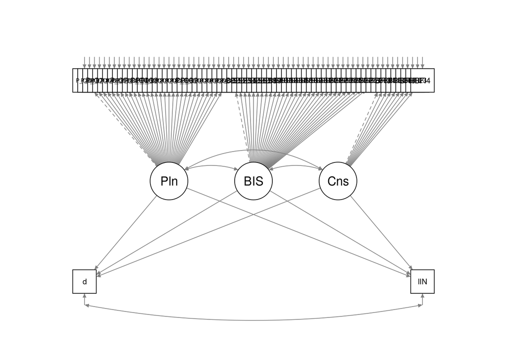

```r
semPaths(hypo2.fc.loginr.fit, style="LISREL")
```

# Hypothesis 3

3.) The hypothesis about the relation of SES to personality traits will be tested by regressing INR on Planfulness, Conscientiousness, and Impulsivity in a single regression model. We expect higher Planfulness, and Conscientiousness, and lower Impulsivity, to be associated with higher INR.

```r
hypo3 ='
  Planfulness =~ P_Q3RTP + P_Q1TP + P_Q7TP + P_Q11RTP + P_Q14TP + P_Q20RTP + P_Q23TP + P_QR25TP +  P_Q28TP +  P_Q30RTP + P_Q2RCS +  P_Q4RCS + P_Q5CS +  P_Q8CS +  P_Q12RCS +  P_Q15CS + P_Q17CS +   P_Q18RCS + P_Q21RCS +   P_Q26CS + P_Q6RMF +  P_Q9MF +   P_Q10RMF +  P_Q13RMF +  P_Q16MF +   P_Q19MF +   P_Q22RMF +  P_Q24MF +   P_Q27MF +   P_Q29RMF
  BIS =~ BIS1 + BIS2 +  BIS3 + BIS4 +   BIS5 +  BIS6 +  BIS7 +  BIS8 +  BIS9 +  BIS10 + BIS11 + BIS12 + BIS13 + BIS14 +    BIS15 +  BIS16 + BIS17 + BIS18 + BIS19 + BIS20 + BIS21 + BIS22 + BIS23 + BIS24 + BIS25 + BIS26 + BIS27 + BIS28 +       BIS29 +   BIS30
  Consci =~ BFI3 + BFI13 + BFI28 + BFI33 + BFI38 + BFI8 + BFI18 + BFI23 + BFI43
  Planfulness ~~ 0*BIS
  Planfulness ~~ 0*Consci
  BIS ~~ 0*Consci
  INR ~ Planfulness
  INR ~ Consci
  INR ~ BIS
'
hypo3.fit = cfa(hypo3, data = data)
summary(hypo3.fit, fit.measures=TRUE, standardized=TRUE)
```

```
## lavaan 0.6-3 ended normally after 177 iterations
##
##   Optimization method                           NLMINB
##   Number of free parameters                        142
##
##                                                   Used       Total
##   Number of observations                          1026        1100
##
##   Estimator                                         ML
##   Model Fit Test Statistic                   14695.674
##   Degrees of freedom                              2343
##   P-value (Chi-square)                           0.000
##
## Model test baseline model:
##
##   Minimum Function Test Statistic            29405.941
##   Degrees of freedom                              2415
##   P-value                                        0.000
##
## User model versus baseline model:
##
##   Comparative Fit Index (CFI)                    0.542
##   Tucker-Lewis Index (TLI)                       0.528
##
## Loglikelihood and Information Criteria:
##
##   Loglikelihood user model (H0)             -88436.340
##   Loglikelihood unrestricted model (H1)     -81088.503
##
##   Number of free parameters                        142
##   Akaike (AIC)                              177156.680
##   Bayesian (BIC)                            177857.226
##   Sample-size adjusted Bayesian (BIC)       177406.219
##
## Root Mean Square Error of Approximation:
##
##   RMSEA                                          0.072
##   90 Percent Confidence Interval          0.071  0.073
##   P-value RMSEA <= 0.05                          0.000
##
```

[output cut: 160 more lines]

```
##    .BIS29             0.927    0.041   22.501    0.000    0.927    0.947
##    .BIS30             0.629    0.028   22.266    0.000    0.629    0.874
##    .BFI3              0.313    0.016   19.916    0.000    0.313    0.585
##    .BFI13             0.289    0.014   20.616    0.000    0.289    0.654
##    .BFI28             0.464    0.024   19.726    0.000    0.464    0.569
##    .BFI33             0.347    0.018   19.409    0.000    0.347    0.544
##    .BFI38             0.570    0.028   20.527    0.000    0.570    0.645
##    .BFI8              0.907    0.044   20.418    0.000    0.907    0.633
##    .BFI18             1.108    0.054   20.342    0.000    1.108    0.625
##    .BFI23             0.868    0.045   19.228    0.000    0.868    0.530
##    .BFI43             1.039    0.050   20.852    0.000    1.039    0.681
##    .INR              34.062    1.511   22.539    0.000   34.062    0.952
##     Planfulness       0.023    0.009    2.419    0.016    1.000    1.000
##     BIS               0.141    0.017    8.108    0.000    1.000    1.000
##     Consci            0.222    0.021   10.793    0.000    1.000    1.000
```

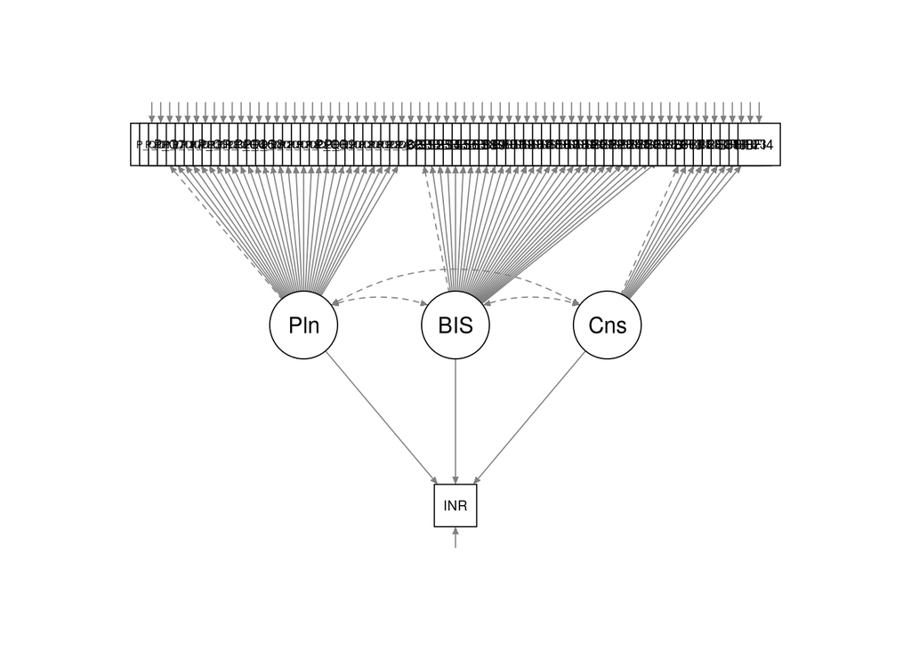

```r
semPaths(hypo3.fit, style="LISREL")
```

## Measurement invariance

```r
hypo3.cmod ='
  Planfulness =~ P_Q3RTP + P_Q1TP + P_Q7TP + P_Q11RTP + P_Q14TP + P_Q20RTP + P_Q23TP + P_QR25TP +  P_Q28TP +  P_Q30RTP + P_Q2RCS +  P_Q4RCS + P_Q5CS +  P_Q8CS +  P_Q12RCS +  P_Q15CS + P_Q17CS +   P_Q18RCS + P_Q21RCS +   P_Q26CS + P_Q6RMF +  P_Q9MF +   P_Q10RMF +  P_Q13RMF +  P_Q16MF +   P_Q19MF +   P_Q22RMF +  P_Q24MF +   P_Q27MF +   P_Q29RMF
  BIS =~ BIS1 + BIS2 +  BIS3 + BIS4 +   BIS5 +  BIS6 +  BIS7 +  BIS8 +  BIS9 +  BIS10 + BIS11 + BIS12 + BIS13 + BIS14 +    BIS15 +  BIS16 + BIS17 + BIS18 + BIS19 + BIS20 + BIS21 + BIS22 + BIS23 + BIS24 + BIS25 + BIS26 + BIS27 + BIS28 +       BIS29 +   BIS30
  Consci =~ BFI3 + BFI13 + BFI28 + BFI33 + BFI38 + BFI8 + BFI18 + BFI23 + BFI43
  Planfulness ~~ 0*BIS
  Planfulness ~~ 0*Consci
  BIS ~~ 0*Consci
  INR ~ Planfulness
  INR ~ Consci
  INR ~ BIS
'
hypo3.cmod.fit = cfa(hypo3.cmod, data = data)
summary(hypo3.cmod.fit)
```

```
## lavaan 0.6-3 ended normally after 177 iterations
##
##   Optimization method                           NLMINB
##   Number of free parameters                        142
##
##                                                   Used       Total
##   Number of observations                          1026        1100
##
##   Estimator                                         ML
##   Model Fit Test Statistic                   14695.674
##   Degrees of freedom                              2343
##   P-value (Chi-square)                           0.000
##
## Parameter Estimates:
##
##   Information                                 Expected
##   Information saturated (h1) model          Structured
##   Standard Errors                             Standard
##
## Latent Variables:
##                    Estimate  Std.Err  z-value  P(>|z|)
##   Planfulness =~
##     P_Q3RTP           1.000
##     P_Q1TP            1.880    0.415    4.531    0.000
##     P_Q7TP            3.962    0.827    4.793    0.000
##     P_Q11RTP          3.049    0.666    4.576    0.000
##     P_Q14TP           3.349    0.707    4.736    0.000
##     P_Q20RTP          4.499    0.941    4.778    0.000
##     P_Q23TP           1.850    0.419    4.417    0.000
##     P_QR25TP          1.379    0.353    3.910    0.000
##     P_Q28TP           1.570    0.372    4.223    0.000
##     P_Q30RTP          3.754    0.794    4.728    0.000
##     P_Q2RCS           2.444    0.541    4.517    0.000
##     P_Q4RCS           2.433    0.547    4.446    0.000
##     P_Q5CS            3.466    0.724    4.786    0.000
##     P_Q8CS            3.377    0.705    4.787    0.000
##     P_Q12RCS          2.688    0.597    4.502    0.000
##     P_Q15CS           3.216    0.671    4.792    0.000
##     P_Q17CS           2.973    0.623    4.772    0.000
##     P_Q18RCS          1.705    0.415    4.105    0.000
```

[output cut: 129 more lines]

```
##    .BIS29             0.927    0.041   22.501    0.000
##    .BIS30             0.629    0.028   22.266    0.000
##    .BFI3              0.313    0.016   19.916    0.000
##    .BFI13             0.289    0.014   20.616    0.000
##    .BFI28             0.464    0.024   19.726    0.000
##    .BFI33             0.347    0.018   19.409    0.000
##    .BFI38             0.570    0.028   20.527    0.000
##    .BFI8              0.907    0.044   20.418    0.000
##    .BFI18             1.108    0.054   20.342    0.000
##    .BFI23             0.868    0.045   19.228    0.000
##    .BFI43             1.039    0.050   20.852    0.000
##    .INR              34.062    1.511   22.539    0.000
##     Planfulness       0.023    0.009    2.419    0.016
##     BIS               0.141    0.017    8.108    0.000
##     Consci            0.222    0.021   10.793    0.000
```

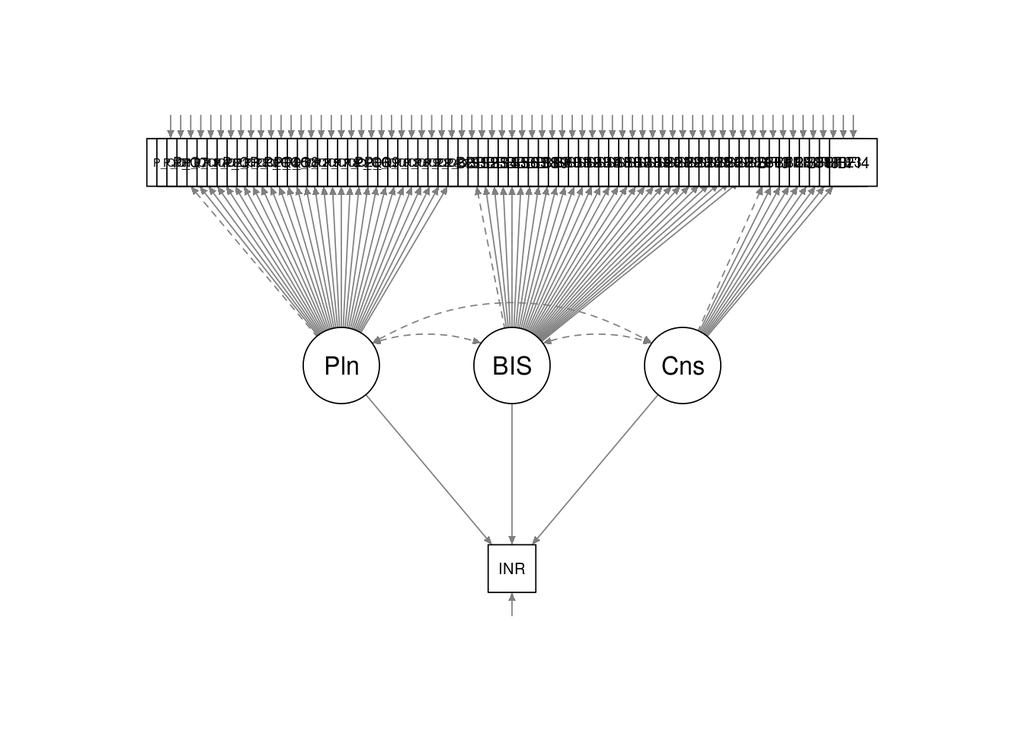

```r
semPaths(hypo3.cmod.fit, style="LISREL")
```

## Free Cov

```r
hypo3.fc ='
  Planfulness =~ P_Q3RTP + P_Q1TP + P_Q7TP + P_Q11RTP + P_Q14TP + P_Q20RTP + P_Q23TP + P_QR25TP +  P_Q28TP +  P_Q30RTP + P_Q2RCS +  P_Q4RCS + P_Q5CS +  P_Q8CS +  P_Q12RCS +  P_Q15CS + P_Q17CS +   P_Q18RCS + P_Q21RCS +   P_Q26CS + P_Q6RMF +  P_Q9MF +   P_Q10RMF +  P_Q13RMF +  P_Q16MF +   P_Q19MF +   P_Q22RMF +  P_Q24MF +   P_Q27MF +   P_Q29RMF
  BIS =~ BIS1 + BIS2 +  BIS3 + BIS4 +   BIS5 +  BIS6 +  BIS7 +  BIS8 +  BIS9 +  BIS10 + BIS11 + BIS12 + BIS13 + BIS14 +    BIS15 +  BIS16 + BIS17 + BIS18 + BIS19 + BIS20 + BIS21 + BIS22 + BIS23 + BIS24 + BIS25 + BIS26 + BIS27 + BIS28 +       BIS29 +   BIS30
  Consci =~ BFI3 + BFI13 + BFI28 + BFI33 + BFI38 + BFI8 + BFI18 + BFI23 + BFI43
  INR ~ Planfulness
  INR ~ Consci
  INR ~ BIS
'
hypo3.fc.fit = cfa(hypo3.fc, data = data)
summary(hypo3.fc.fit, fit.measures=TRUE, standardized=TRUE)
```

```
## lavaan 0.6-3 ended normally after 191 iterations
##
##   Optimization method                           NLMINB
##   Number of free parameters                        145
##
##                                                   Used       Total
##   Number of observations                          1026        1100
##
##   Estimator                                         ML
##   Model Fit Test Statistic                   13202.585
##   Degrees of freedom                              2340
##   P-value (Chi-square)                           0.000
##
## Model test baseline model:
##
##   Minimum Function Test Statistic            29405.941
##   Degrees of freedom                              2415
##   P-value                                        0.000
##
## User model versus baseline model:
##
##   Comparative Fit Index (CFI)                    0.598
##   Tucker-Lewis Index (TLI)                       0.585
##
## Loglikelihood and Information Criteria:
##
##   Loglikelihood user model (H0)             -87689.796
##   Loglikelihood unrestricted model (H1)     -81088.503
##
##   Number of free parameters                        145
##   Akaike (AIC)                              175669.591
##   Bayesian (BIC)                            176384.937
##   Sample-size adjusted Bayesian (BIC)       175924.402
##
## Root Mean Square Error of Approximation:
##
##   RMSEA                                          0.067
##   90 Percent Confidence Interval          0.066  0.068
##   P-value RMSEA <= 0.05                          0.000
##
```

[output cut: 160 more lines]

```
##    .BIS29             0.917    0.041   22.505    0.000    0.917    0.936
##    .BIS30             0.593    0.027   22.197    0.000    0.593    0.825
##    .BFI3              0.336    0.016   20.910    0.000    0.336    0.628
##    .BFI13             0.299    0.014   21.254    0.000    0.299    0.677
##    .BFI28             0.485    0.024   20.646    0.000    0.485    0.595
##    .BFI33             0.358    0.018   20.342    0.000    0.358    0.560
##    .BFI38             0.556    0.027   20.919    0.000    0.556    0.629
##    .BFI8              0.859    0.042   20.685    0.000    0.859    0.599
##    .BFI18             1.092    0.052   20.822    0.000    1.092    0.616
##    .BFI23             0.869    0.043   20.046    0.000    0.869    0.531
##    .BFI43             0.965    0.046   20.947    0.000    0.965    0.633
##    .INR              33.872    1.510   22.430    0.000   33.872    0.944
##     Planfulness       0.028    0.010    2.695    0.007    1.000    1.000
##     BIS               0.176    0.019    9.301    0.000    1.000    1.000
##     Consci            0.199    0.019   10.266    0.000    1.000    1.000
```

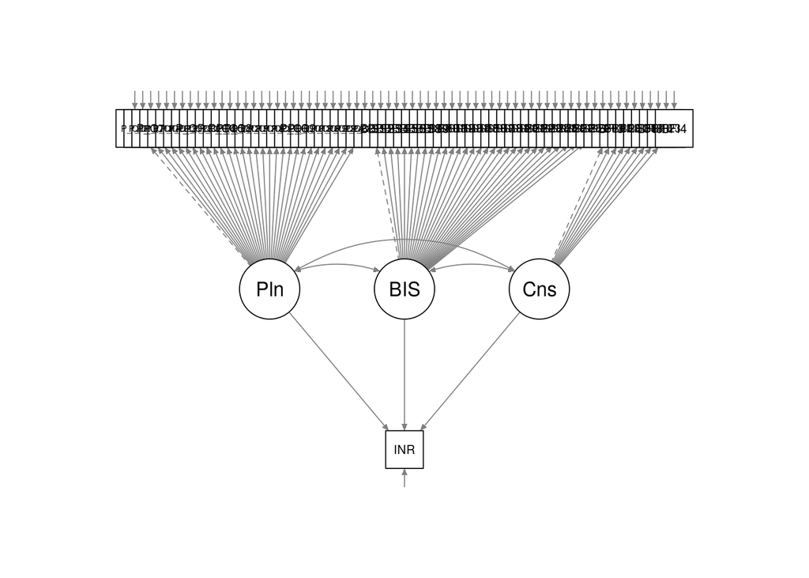

```r
semPaths(hypo3.fc.fit, style="LISREL")
```

## Log INR

```r
hypo3.loginr ='
  Planfulness =~ P_Q3RTP + P_Q1TP + P_Q7TP + P_Q11RTP + P_Q14TP + P_Q20RTP + P_Q23TP + P_QR25TP +  P_Q28TP +  P_Q30RTP + P_Q2RCS +  P_Q4RCS + P_Q5CS +  P_Q8CS +  P_Q12RCS +  P_Q15CS + P_Q17CS +   P_Q18RCS + P_Q21RCS +   P_Q26CS + P_Q6RMF +  P_Q9MF +   P_Q10RMF +  P_Q13RMF +  P_Q16MF +   P_Q19MF +   P_Q22RMF +  P_Q24MF +   P_Q27MF +   P_Q29RMF
  BIS =~ BIS1 + BIS2 +  BIS3 + BIS4 +   BIS5 +  BIS6 +  BIS7 +  BIS8 +  BIS9 +  BIS10 + BIS11 + BIS12 + BIS13 + BIS14 +    BIS15 +  BIS16 + BIS17 + BIS18 + BIS19 + BIS20 + BIS21 + BIS22 + BIS23 + BIS24 + BIS25 + BIS26 + BIS27 + BIS28 +       BIS29 +   BIS30
  Consci =~ BFI3 + BFI13 + BFI28 + BFI33 + BFI38 + BFI8 + BFI18 + BFI23 + BFI43
  Planfulness ~~ 0*BIS
  Planfulness ~~ 0*Consci
  BIS ~~ 0*Consci
  logINR ~ Planfulness
  logINR ~ Consci
  logINR ~ BIS
'
hypo3.loginr.fit = cfa(hypo3.loginr, data = data)
summary(hypo3.loginr.fit, fit.measures=TRUE, standardized=TRUE)
```

```
## lavaan 0.6-3 ended normally after 111 iterations
##
##   Optimization method                           NLMINB
##   Number of free parameters                        142
##
##                                                   Used       Total
##   Number of observations                          1026        1100
##
##   Estimator                                         ML
##   Model Fit Test Statistic                   14755.244
##   Degrees of freedom                              2343
##   P-value (Chi-square)                           0.000
##
## Model test baseline model:
##
##   Minimum Function Test Statistic            29476.081
##   Degrees of freedom                              2415
##   P-value                                        0.000
##
## User model versus baseline model:
##
##   Comparative Fit Index (CFI)                    0.541
##   Tucker-Lewis Index (TLI)                       0.527
##
## Loglikelihood and Information Criteria:
##
##   Loglikelihood user model (H0)             -86602.906
##   Loglikelihood unrestricted model (H1)     -79225.284
##
##   Number of free parameters                        142
##   Akaike (AIC)                              173489.812
##   Bayesian (BIC)                            174190.358
##   Sample-size adjusted Bayesian (BIC)       173739.351
##
## Root Mean Square Error of Approximation:
##
##   RMSEA                                          0.072
##   90 Percent Confidence Interval          0.071  0.073
##   P-value RMSEA <= 0.05                          0.000
##
```

[output cut: 160 more lines]

```
##    .BIS29             0.927    0.041   22.502    0.000    0.927    0.947
##    .BIS30             0.629    0.028   22.266    0.000    0.629    0.874
##    .BFI3              0.312    0.016   19.908    0.000    0.312    0.584
##    .BFI13             0.289    0.014   20.620    0.000    0.289    0.655
##    .BFI28             0.464    0.024   19.726    0.000    0.464    0.569
##    .BFI33             0.347    0.018   19.414    0.000    0.347    0.544
##    .BFI38             0.570    0.028   20.531    0.000    0.570    0.645
##    .BFI8              0.907    0.044   20.416    0.000    0.907    0.633
##    .BFI18             1.108    0.054   20.343    0.000    1.108    0.625
##    .BFI23             0.869    0.045   19.236    0.000    0.869    0.531
##    .BFI43             1.039    0.050   20.850    0.000    1.039    0.681
##    .logINR            0.954    0.042   22.503    0.000    0.954    0.939
##     Planfulness       0.023    0.009    2.420    0.016    1.000    1.000
##     BIS               0.141    0.017    8.112    0.000    1.000    1.000
##     Consci            0.222    0.021   10.806    0.000    1.000    1.000
```

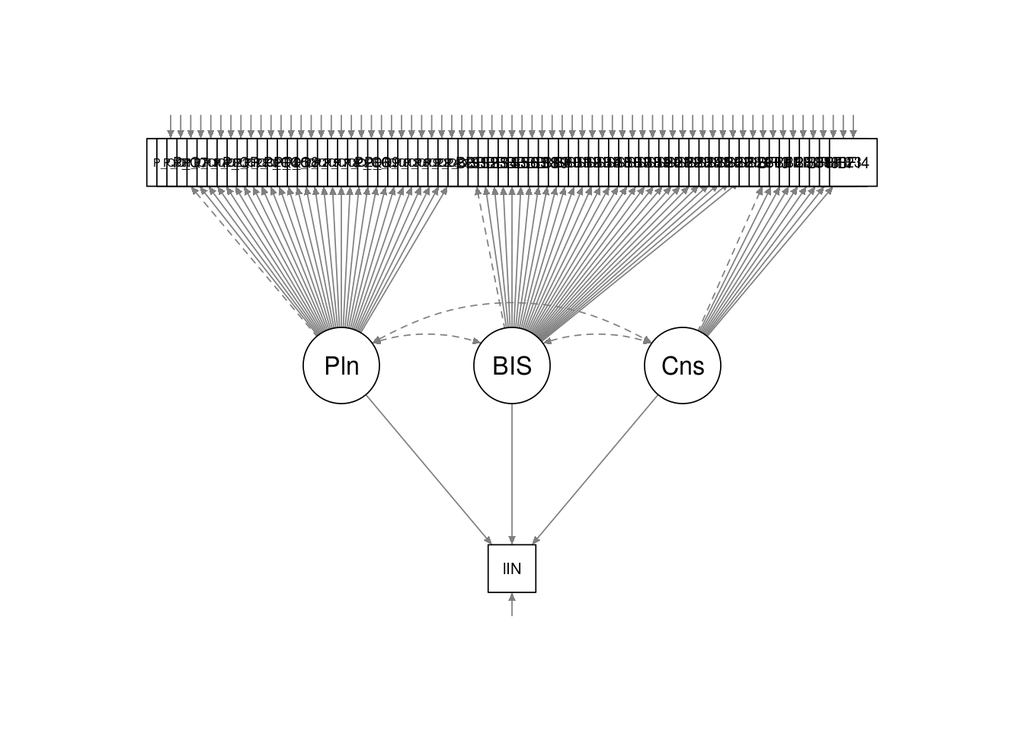

```r
semPaths(hypo3.loginr.fit, style="LISREL")
```

### Free cov

```r
hypo3.fc.loginr ='
  Planfulness =~ P_Q3RTP + P_Q1TP + P_Q7TP + P_Q11RTP + P_Q14TP + P_Q20RTP + P_Q23TP + P_QR25TP +  P_Q28TP +  P_Q30RTP + P_Q2RCS +  P_Q4RCS + P_Q5CS +  P_Q8CS +  P_Q12RCS +  P_Q15CS + P_Q17CS +   P_Q18RCS + P_Q21RCS +   P_Q26CS + P_Q6RMF +  P_Q9MF +   P_Q10RMF +  P_Q13RMF +  P_Q16MF +   P_Q19MF +   P_Q22RMF +  P_Q24MF +   P_Q27MF +   P_Q29RMF
  BIS =~ BIS1 + BIS2 +  BIS3 + BIS4 +   BIS5 +  BIS6 +  BIS7 +  BIS8 +  BIS9 +  BIS10 + BIS11 + BIS12 + BIS13 + BIS14 +    BIS15 +  BIS16 + BIS17 + BIS18 + BIS19 + BIS20 + BIS21 + BIS22 + BIS23 + BIS24 + BIS25 + BIS26 + BIS27 + BIS28 +       BIS29 +   BIS30
  Consci =~ BFI3 + BFI13 + BFI28 + BFI33 + BFI38 + BFI8 + BFI18 + BFI23 + BFI43
  logINR ~ Planfulness
  logINR ~ Consci
  logINR ~ BIS
'
hypo3.fc.loginr.fit = cfa(hypo3.fc.loginr, data = data)
summary(hypo3.fc.loginr.fit, fit.measures=TRUE, standardized=TRUE)
```

```
## lavaan 0.6-3 ended normally after 117 iterations
##
##   Optimization method                           NLMINB
##   Number of free parameters                        145
##
##                                                   Used       Total
##   Number of observations                          1026        1100
##
##   Estimator                                         ML
##   Model Fit Test Statistic                   13261.490
##   Degrees of freedom                              2340
##   P-value (Chi-square)                           0.000
##
## Model test baseline model:
##
##   Minimum Function Test Statistic            29476.081
##   Degrees of freedom                              2415
##   P-value                                        0.000
##
## User model versus baseline model:
##
##   Comparative Fit Index (CFI)                    0.596
##   Tucker-Lewis Index (TLI)                       0.583
##
## Loglikelihood and Information Criteria:
##
##   Loglikelihood user model (H0)             -85856.029
##   Loglikelihood unrestricted model (H1)     -79225.284
##
##   Number of free parameters                        145
##   Akaike (AIC)                              172002.057
##   Bayesian (BIC)                            172717.403
##   Sample-size adjusted Bayesian (BIC)       172256.868
##
## Root Mean Square Error of Approximation:
##
##   RMSEA                                          0.067
##   90 Percent Confidence Interval          0.066  0.069
##   P-value RMSEA <= 0.05                          0.000
##
```

[output cut: 160 more lines]

```
##    .BIS29             0.917    0.041   22.506    0.000    0.917    0.937
##    .BIS30             0.593    0.027   22.197    0.000    0.593    0.825
##    .BFI3              0.335    0.016   20.906    0.000    0.335    0.627
##    .BFI13             0.299    0.014   21.257    0.000    0.299    0.678
##    .BFI28             0.485    0.024   20.646    0.000    0.485    0.594
##    .BFI33             0.358    0.018   20.346    0.000    0.358    0.561
##    .BFI38             0.557    0.027   20.923    0.000    0.557    0.629
##    .BFI8              0.858    0.041   20.683    0.000    0.858    0.599
##    .BFI18             1.092    0.052   20.822    0.000    1.092    0.616
##    .BFI23             0.870    0.043   20.052    0.000    0.870    0.531
##    .BFI43             0.964    0.046   20.946    0.000    0.964    0.633
##    .logINR            0.947    0.042   22.344    0.000    0.947    0.931
##     Planfulness       0.028    0.010    2.695    0.007    1.000    1.000
##     BIS               0.176    0.019    9.303    0.000    1.000    1.000
##     Consci            0.199    0.019   10.279    0.000    1.000    1.000
```

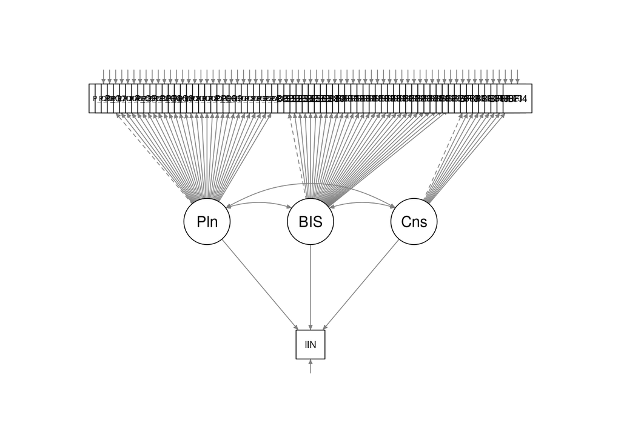

```r
semPaths(hypo3.fc.loginr.fit, style="LISREL")
```

# Examine simple covariance

```r
exp1 ='
  Planfulness =~ P_Q3RTP + P_Q1TP + P_Q7TP + P_Q11RTP + P_Q14TP + P_Q20RTP + P_Q23TP + P_QR25TP +  P_Q28TP +  P_Q30RTP + P_Q2RCS +  P_Q4RCS + P_Q5CS +  P_Q8CS +  P_Q12RCS +  P_Q15CS + P_Q17CS +   P_Q18RCS + P_Q21RCS +   P_Q26CS + P_Q6RMF +  P_Q9MF +   P_Q10RMF +  P_Q13RMF +  P_Q16MF +   P_Q19MF +   P_Q22RMF +  P_Q24MF +   P_Q27MF +   P_Q29RMF
  BIS =~ BIS1 + BIS2 +  BIS3 + BIS4 +   BIS5 +  BIS6 +  BIS7 +  BIS8 +  BIS9 +  BIS10 + BIS11 + BIS12 + BIS13 + BIS14 +    BIS15 +  BIS16 + BIS17 + BIS18 + BIS19 + BIS20 + BIS21 + BIS22 + BIS23 + BIS24 + BIS25 + BIS26 + BIS27 + BIS28 +       BIS29 +   BIS30
  Consci =~ BFI3 + BFI13 + BFI28 + BFI33 + BFI38 + BFI8 + BFI18 + BFI23 + BFI43
  bfac =~ 1*b
  dfac =~ 1*d
  INRfac =~ 1*INR
  Planfulness ~~ BIS + Consci + dfac + bfac + INRfac
  BIS ~~ Consci + dfac + bfac + INRfac
  Consci ~~ dfac + bfac + INRfac
  dfac ~~ bfac + INRfac
  bfac ~~ INRfac
'
exp1.fit = cfa(exp1, data = data)
summary(exp1.fit, stand = T)
```

```
## lavaan 0.6-3 ended normally after 208 iterations
##
##   Optimization method                           NLMINB
##   Number of free parameters                        156
##
##                                                   Used       Total
##   Number of observations                          1018        1100
##
##   Estimator                                         ML
##   Model Fit Test Statistic                   13307.574
##   Degrees of freedom                              2472
##   P-value (Chi-square)                           0.000
##
## Parameter Estimates:
##
##   Information                                 Expected
##   Information saturated (h1) model          Structured
##   Standard Errors                             Standard
##
## Latent Variables:
##                    Estimate  Std.Err  z-value  P(>|z|)   Std.lv  Std.all
##   Planfulness =~
##     P_Q3RTP           1.000                               0.168    0.174
##     P_Q1TP            1.672    0.337    4.966    0.000    0.280    0.370
##     P_Q7TP            3.479    0.653    5.325    0.000    0.583    0.660
##     P_Q11RTP          2.733    0.543    5.037    0.000    0.458    0.401
##     P_Q14TP           2.900    0.554    5.234    0.000    0.486    0.536
##     P_Q20RTP          4.222    0.792    5.329    0.000    0.708    0.667
##     P_Q23TP           1.574    0.330    4.770    0.000    0.264    0.308
##     P_QR25TP          1.356    0.312    4.341    0.000    0.227    0.228
##     P_Q28TP           1.299    0.292    4.454    0.000    0.218    0.245
##     P_Q30RTP          3.365    0.642    5.244    0.000    0.564    0.547
##     P_Q2RCS           2.375    0.472    5.034    0.000    0.398    0.399
##     P_Q4RCS           2.331    0.472    4.936    0.000    0.391    0.359
##     P_Q5CS            3.001    0.565    5.308    0.000    0.503    0.630
##     P_Q8CS            2.962    0.557    5.314    0.000    0.496    0.640
##     P_Q12RCS          2.558    0.512    4.995    0.000    0.429    0.382
##     P_Q15CS           2.803    0.527    5.319    0.000    0.470    0.649
##     P_Q17CS           2.575    0.487    5.289    0.000    0.432    0.602
##     P_Q18RCS          1.696    0.370    4.587    0.000    0.284    0.268
```

[output cut: 149 more lines]

```
##    .BFI33             0.343    0.017   20.148    0.000    0.343    0.546
##    .BFI38             0.557    0.027   20.848    0.000    0.557    0.628
##    .BFI8              0.859    0.042   20.620    0.000    0.859    0.599
##    .BFI18             1.087    0.052   20.732    0.000    1.087    0.613
##    .BFI23             0.868    0.043   19.991    0.000    0.868    0.530
##    .BFI43             0.964    0.046   20.879    0.000    0.964    0.632
##    .b                 0.000                               0.000    0.000
##    .d                 0.000                               0.000    0.000
##    .INR               0.000                               0.000    0.000
##     Planfulness       0.028    0.010    2.697    0.007    1.000    1.000
##     BIS               0.178    0.019    9.332    0.000    1.000    1.000
##     Consci            0.201    0.020   10.270    0.000    1.000    1.000
##     bfac              0.015    0.001   22.561    0.000    1.000    1.000
##     dfac              0.000    0.000   22.561    0.000    1.000    1.000
##     INRfac           36.016    1.596   22.561    0.000    1.000    1.000
```

```r
semPaths(exp1.fit, style="LISREL")
```

[output not shown]

## Measurement invariance

```r
exp1.cmod ='
  Planfulness =~ P_Q3RTP + P_Q1TP + P_Q7TP + P_Q11RTP + P_Q14TP + P_Q20RTP + P_Q23TP + P_QR25TP +  P_Q28TP +  P_Q30RTP + P_Q2RCS +  P_Q4RCS + P_Q5CS +  P_Q8CS +  P_Q12RCS +  P_Q15CS + P_Q17CS +   P_Q18RCS + P_Q21RCS +   P_Q26CS + P_Q6RMF +  P_Q9MF +   P_Q10RMF +  P_Q13RMF +  P_Q16MF +   P_Q19MF +   P_Q22RMF +  P_Q24MF +   P_Q27MF +   P_Q29RMF
  BIS =~ BIS1 + BIS2 +  BIS3 + BIS4 +   BIS5 +  BIS6 +  BIS7 +  BIS8 +  BIS9 +  BIS10 + BIS11 + BIS12 + BIS13 + BIS14 +    BIS15 +  BIS16 + BIS17 + BIS18 + BIS19 + BIS20 + BIS21 + BIS22 + BIS23 + BIS24 + BIS25 + BIS26 + BIS27 + BIS28 +       BIS29 +   BIS30
  Consci =~ BFI3 + BFI13 + BFI28 + BFI33 + BFI38 + BFI8 + BFI18 + BFI23 + BFI43
  bfac =~ 1*b
  dfac =~ 1*d
  INRfac =~ 1*INR
  Planfulness ~~ BIS + Consci + dfac + bfac + INRfac
  BIS ~~ Consci + dfac + bfac + INRfac
  Consci ~~ dfac + bfac + INRfac
  dfac ~~ bfac + INRfac
  bfac ~~ INRfac
'
exp1.cmod.fit = cfa(exp1.cmod, data = data)
summary(exp1.cmod.fit, stand = T)
```

```
## lavaan 0.6-3 ended normally after 208 iterations
##
##   Optimization method                           NLMINB
##   Number of free parameters                        156
##
##                                                   Used       Total
##   Number of observations                          1018        1100
##
##   Estimator                                         ML
##   Model Fit Test Statistic                   13307.574
##   Degrees of freedom                              2472
##   P-value (Chi-square)                           0.000
##
## Parameter Estimates:
##
##   Information                                 Expected
##   Information saturated (h1) model          Structured
##   Standard Errors                             Standard
##
## Latent Variables:
##                    Estimate  Std.Err  z-value  P(>|z|)   Std.lv  Std.all
##   Planfulness =~
##     P_Q3RTP           1.000                               0.168    0.174
##     P_Q1TP            1.672    0.337    4.966    0.000    0.280    0.370
##     P_Q7TP            3.479    0.653    5.325    0.000    0.583    0.660
##     P_Q11RTP          2.733    0.543    5.037    0.000    0.458    0.401
##     P_Q14TP           2.900    0.554    5.234    0.000    0.486    0.536
##     P_Q20RTP          4.222    0.792    5.329    0.000    0.708    0.667
##     P_Q23TP           1.574    0.330    4.770    0.000    0.264    0.308
##     P_QR25TP          1.356    0.312    4.341    0.000    0.227    0.228
##     P_Q28TP           1.299    0.292    4.454    0.000    0.218    0.245
##     P_Q30RTP          3.365    0.642    5.244    0.000    0.564    0.547
##     P_Q2RCS           2.375    0.472    5.034    0.000    0.398    0.399
##     P_Q4RCS           2.331    0.472    4.936    0.000    0.391    0.359
##     P_Q5CS            3.001    0.565    5.308    0.000    0.503    0.630
##     P_Q8CS            2.962    0.557    5.314    0.000    0.496    0.640
##     P_Q12RCS          2.558    0.512    4.995    0.000    0.429    0.382
##     P_Q15CS           2.803    0.527    5.319    0.000    0.470    0.649
##     P_Q17CS           2.575    0.487    5.289    0.000    0.432    0.602
##     P_Q18RCS          1.696    0.370    4.587    0.000    0.284    0.268
```

[output cut: 149 more lines]

```
##    .BFI33             0.343    0.017   20.148    0.000    0.343    0.546
##    .BFI38             0.557    0.027   20.848    0.000    0.557    0.628
##    .BFI8              0.859    0.042   20.620    0.000    0.859    0.599
##    .BFI18             1.087    0.052   20.732    0.000    1.087    0.613
##    .BFI23             0.868    0.043   19.991    0.000    0.868    0.530
##    .BFI43             0.964    0.046   20.879    0.000    0.964    0.632
##    .b                 0.000                               0.000    0.000
##    .d                 0.000                               0.000    0.000
##    .INR               0.000                               0.000    0.000
##     Planfulness       0.028    0.010    2.697    0.007    1.000    1.000
##     BIS               0.178    0.019    9.332    0.000    1.000    1.000
##     Consci            0.201    0.020   10.270    0.000    1.000    1.000
##     bfac              0.015    0.001   22.561    0.000    1.000    1.000
##     dfac              0.000    0.000   22.561    0.000    1.000    1.000
##     INRfac           36.016    1.596   22.561    0.000    1.000    1.000
```

```r
semPaths(exp1.cmod.fit, style="LISREL")
```

[output not shown]

```r
exp1.loginr ='
  Planfulness =~ P_Q3RTP + P_Q1TP + P_Q7TP + P_Q11RTP + P_Q14TP + P_Q20RTP + P_Q23TP + P_QR25TP +  P_Q28TP +  P_Q30RTP + P_Q2RCS +  P_Q4RCS + P_Q5CS +  P_Q8CS +  P_Q12RCS +  P_Q15CS + P_Q17CS +   P_Q18RCS + P_Q21RCS +   P_Q26CS + P_Q6RMF +  P_Q9MF +   P_Q10RMF +  P_Q13RMF +  P_Q16MF +   P_Q19MF +   P_Q22RMF +  P_Q24MF +   P_Q27MF +   P_Q29RMF
  BIS =~ BIS1 + BIS2 +  BIS3 + BIS4 +   BIS5 +  BIS6 +  BIS7 +  BIS8 +  BIS9 +  BIS10 + BIS11 + BIS12 + BIS13 + BIS14 +    BIS15 +  BIS16 + BIS17 + BIS18 + BIS19 + BIS20 + BIS21 + BIS22 + BIS23 + BIS24 + BIS25 + BIS26 + BIS27 + BIS28 +       BIS29 +   BIS30
  Consci =~ BFI3 + BFI13 + BFI28 + BFI33 + BFI38 + BFI8 + BFI18 + BFI23 + BFI43
  bfac =~ 1*b
  dfac =~ 1*d
  INRfac =~ 1*INR
  Planfulness ~~ BIS + Consci + dfac + bfac + INRfac
  BIS ~~ Consci + dfac + bfac + INRfac
  Consci ~~ dfac + bfac + INRfac
  dfac ~~ bfac + INRfac
  bfac ~~ INRfac
'
exp1.loginr.fit = cfa(exp1.loginr, data = data)
summary(exp1.loginr.fit, stand = T)
```

```
## lavaan 0.6-3 ended normally after 208 iterations
##
##   Optimization method                           NLMINB
##   Number of free parameters                        156
##
##                                                   Used       Total
##   Number of observations                          1018        1100
##
##   Estimator                                         ML
##   Model Fit Test Statistic                   13307.574
##   Degrees of freedom                              2472
##   P-value (Chi-square)                           0.000
##
## Parameter Estimates:
##
##   Information                                 Expected
##   Information saturated (h1) model          Structured
##   Standard Errors                             Standard
##
## Latent Variables:
##                    Estimate  Std.Err  z-value  P(>|z|)   Std.lv  Std.all
##   Planfulness =~
##     P_Q3RTP           1.000                               0.168    0.174
##     P_Q1TP            1.672    0.337    4.966    0.000    0.280    0.370
##     P_Q7TP            3.479    0.653    5.325    0.000    0.583    0.660
##     P_Q11RTP          2.733    0.543    5.037    0.000    0.458    0.401
##     P_Q14TP           2.900    0.554    5.234    0.000    0.486    0.536
##     P_Q20RTP          4.222    0.792    5.329    0.000    0.708    0.667
##     P_Q23TP           1.574    0.330    4.770    0.000    0.264    0.308
##     P_QR25TP          1.356    0.312    4.341    0.000    0.227    0.228
##     P_Q28TP           1.299    0.292    4.454    0.000    0.218    0.245
##     P_Q30RTP          3.365    0.642    5.244    0.000    0.564    0.547
##     P_Q2RCS           2.375    0.472    5.034    0.000    0.398    0.399
##     P_Q4RCS           2.331    0.472    4.936    0.000    0.391    0.359
##     P_Q5CS            3.001    0.565    5.308    0.000    0.503    0.630
##     P_Q8CS            2.962    0.557    5.314    0.000    0.496    0.640
##     P_Q12RCS          2.558    0.512    4.995    0.000    0.429    0.382
##     P_Q15CS           2.803    0.527    5.319    0.000    0.470    0.649
##     P_Q17CS           2.575    0.487    5.289    0.000    0.432    0.602
##     P_Q18RCS          1.696    0.370    4.587    0.000    0.284    0.268
```

[output cut: 149 more lines]

```
##    .BFI33             0.343    0.017   20.148    0.000    0.343    0.546
##    .BFI38             0.557    0.027   20.848    0.000    0.557    0.628
##    .BFI8              0.859    0.042   20.620    0.000    0.859    0.599
##    .BFI18             1.087    0.052   20.732    0.000    1.087    0.613
##    .BFI23             0.868    0.043   19.991    0.000    0.868    0.530
##    .BFI43             0.964    0.046   20.879    0.000    0.964    0.632
##    .b                 0.000                               0.000    0.000
##    .d                 0.000                               0.000    0.000
##    .INR               0.000                               0.000    0.000
##     Planfulness       0.028    0.010    2.697    0.007    1.000    1.000
##     BIS               0.178    0.019    9.332    0.000    1.000    1.000
##     Consci            0.201    0.020   10.270    0.000    1.000    1.000
##     bfac              0.015    0.001   22.561    0.000    1.000    1.000
##     dfac              0.000    0.000   22.561    0.000    1.000    1.000
##     INRfac           36.016    1.596   22.561    0.000    1.000    1.000
```

```r
semPaths(exp1.loginr.fit, style="LISREL")
```

[output not shown]